# Total Fitness

### WL2 Avg Gowers

```r
wl2_gowers_2023_prep <- wl2_gowers_2023 %>% rename_with(~paste0(., "_2023"), 6:9)
wl2_gowers_2324_prep <- wl2_gowers_2324 %>% rename_with(~paste0(., "_2024"), 6:9)

wl2_gowers_avg <- bind_rows(wl2_gowers_2023, wl2_gowers_2324) %>%
  group_by(pop, elevation.group, elev_m, Geographic_Dist, Elev_Dist) %>%
  summarise_at(c("GrwSsn_GD_Recent",  "GrwSsn_GD_Historical", "Wtr_Year_GD_Recent", "Wtr_Year_GD_Historical"), c(mean), na.rm = TRUE)
wl2_gowers_avg
```

```
## # A tibble: 23 × 9
## # Groups:   pop, elevation.group, elev_m, Geographic_Dist [23]
##    pop   elevation.group elev_m Geographic_Dist Elev_Dist GrwSsn_GD_Recent
##    <chr> <chr>            <dbl>           <dbl>     <dbl>            <dbl>
##  1 BH    Low               511.         159626.    -1509.            0.312
##  2 CC    Low               313          132498.    -1707             0.418
##  3 CP2   High             2244.          21060.      224.            0.305
##  4 CP3   High             2266.          19415.      246.            0.327
##  5 DPR   Mid              1019.          66246.    -1001.            0.440
##  6 FR    Mid               787          154694.    -1233             0.388
##  7 IH    Low               454.          65203.    -1566.            0.442
##  8 LV1   High             2593.         212682.      573.            0.377
##  9 LV3   High             2354.         213902.      334.            0.378
## 10 LVTR1 High             2741.         213038.      721.            0.402
## # ℹ 13 more rows
## # ℹ 3 more variables: GrwSsn_GD_Historical <dbl>, Wtr_Year_GD_Recent <dbl>,
## #   Wtr_Year_GD_Historical <dbl>
```

[figure not shown]

```r
grw_recent_fig <- wl2_gowers_avg %>%
  ggplot(aes(x=fct_reorder(pop, GrwSsn_GD_Recent), y=GrwSsn_GD_Recent, group=pop, fill=elev_m)) +
  geom_col(width = 0.7,position = position_dodge(0.75)) +
  scale_y_continuous(expand = c(0, 0)) +
  scale_fill_gradient(low = "#F5A540", high = "#0043F0") +
  labs(y="Gowers Envtal Distance \n from WL2", fill="Elevation (m)", x="Population", title = "Recent Climate") +
  theme_classic() +
  theme(text=element_text(size=25), axis.text.x = element_text(angle = 45,  hjust = 1))

grw_historical_fig <- wl2_gowers_avg %>%
  ggplot(aes(x=fct_reorder(pop, GrwSsn_GD_Historical), y=GrwSsn_GD_Historical, group=pop, fill=elev_m)) +
  geom_col(width = 0.7,position = position_dodge(0.75)) +
  scale_y_continuous(expand = c(0, 0)) +
  scale_fill_gradient(low = "#F5A540", high = "#0043F0") +
  labs(y="Gowers Envtal Distance \n from WL2", fill="Elevation (m)", x="Population", title="Historic Climate") +
  theme_classic() +
  theme(text=element_text(size=25), axis.text.x = element_text(angle = 45,  hjust = 1))


plot_grid(grw_historical_fig, grw_recent_fig)
```

```r
#ggsave("../output/Climate/AVG_growthseason_Gowers_fromWL2_2324.png", width = 24, height = 8, units = "in")
```

[figure not shown]

```r
wtr_recent_fig <- wl2_gowers_avg %>%
  ggplot(aes(x=fct_reorder(pop, Wtr_Year_GD_Recent), y=Wtr_Year_GD_Recent, group=pop, fill=elev_m)) +
  geom_col(width = 0.7,position = position_dodge(0.75)) +
  scale_y_continuous(expand = c(0, 0)) +
  scale_fill_gradient(low = "#F5A540", high = "#0043F0") +
  labs(y="Gowers Envtal Distance \n from WL2", fill="Elevation (m)", x="Population", title = "Recent Climate") +
  theme_classic() +
  theme(text=element_text(size=25), axis.text.x = element_text(angle = 45,  hjust = 1))

wtr_historical_fig <- wl2_gowers_avg %>%
  ggplot(aes(x=fct_reorder(pop, Wtr_Year_GD_Historical), y=Wtr_Year_GD_Historical, group=pop, fill=elev_m)) +
  geom_col(width = 0.7,position = position_dodge(0.75)) +
  scale_y_continuous(expand = c(0, 0)) +
  scale_fill_gradient(low = "#F5A540", high = "#0043F0") +
  labs(y="Gowers Envtal Distance \n from WL2", fill="Elevation (m)", x="Population", title="Historic Climate") +
  theme_classic() +
  theme(text=element_text(size=25), axis.text.x = element_text(angle = 45,  hjust = 1))


plot_grid(wtr_historical_fig, wtr_recent_fig)
```

```r
#ggsave("../output/Climate/AVG_wtryr_Gowers_fromWL2_2324.png", width = 24, height = 8, units = "in")
```

#### For Subtraction Distances

```r
wl2_sub_dist_2023_prep <- wl2_sub_dist_2023 %>%
  select(pop:GrwSsn_CWDDist_Historic)
wl2_sub_dist_2324_prep <- wl2_sub_dist_2324 %>%
  select(pop:GrwSsn_CWDDist_Historic)

wl2_sub_dist_avg <- bind_rows(wl2_sub_dist_2023_prep, wl2_sub_dist_2324_prep) %>%
  group_by(pop) %>%
  summarise_at(c("Wtr_Year_TempDist_Recent", "Wtr_Year_PPTDist_Recent", "Wtr_Year_CWDDist_Recent",
                 "Wtr_Year_TempDist_Historic", "Wtr_Year_PPTDist_Historic", "Wtr_Year_CWDDist_Historic",
                 "GrwSsn_TempDist_Recent", "GrwSsn_PPTDist_Recent", "GrwSsn_CWDDist_Recent",
                 "GrwSsn_TempDist_Historic", "GrwSsn_PPTDist_Historic", "GrwSsn_CWDDist_Historic"), c(mean), na.rm = TRUE) %>%
  left_join(wl2_gowers_avg)
wl2_sub_dist_avg
```

```
## # A tibble: 23 × 21
##    pop   Wtr_Year_TempDist_Recent Wtr_Year_PPTDist_Recent Wtr_Year_CWDDist_Rec…¹
##    <chr>                    <dbl>                   <dbl>                  <dbl>
##  1 BH                       8.30                  -1257.                  26.9
##  2 CC                       8.71                   -826.                  10.9
##  3 CP2                     -0.653                  -552.                  13.9
##  4 CP3                     -1.36                   -607.                  -2.78
##  5 DPR                      6.12                   -384.                 -21.5
##  6 FR                       4.97                   -821.                  26.5
##  7 IH                       7.49                   -767.                   0.306
##  8 LV1                     -3.02                    -83.2                  0.822
##  9 LV3                     -3.01                   -115.                  -8.12
## 10 LVTR1                   -3.17                    -24.7                  3.13
## # ℹ 13 more rows
## # ℹ abbreviated name: ¹Wtr_Year_CWDDist_Recent
## # ℹ 17 more variables: Wtr_Year_TempDist_Historic <dbl>,
## #   Wtr_Year_PPTDist_Historic <dbl>, Wtr_Year_CWDDist_Historic <dbl>,
## #   GrwSsn_TempDist_Recent <dbl>, GrwSsn_PPTDist_Recent <dbl>,
## #   GrwSsn_CWDDist_Recent <dbl>, GrwSsn_TempDist_Historic <dbl>,
## #   GrwSsn_PPTDist_Historic <dbl>, GrwSsn_CWDDist_Historic <dbl>, …
```

Correlations

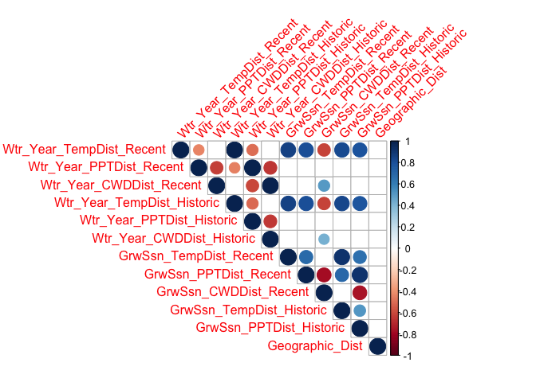

```r
wl2_sub_dist_avgs_scaled <- wl2_sub_dist_avg %>% ungroup() %>%
  select(Wtr_Year_TempDist_Recent:GrwSsn_PPTDist_Historic, Geographic_Dist) %>% scale() #normalize the data so they're all on the same scale

cor.norm = cor(wl2_sub_dist_avgs_scaled) #test correlations among the traits
cor.sig <- cor.mtest(wl2_sub_dist_avgs_scaled, method = "pearson")

corrplot(cor.norm, type="upper",
         tl.srt = 45, p.mat = cor.sig$p,
         sig.level = 0.05, insig="blank")
```

## Load Davis Fitness Components

```r
ucd_establishment <- read_csv("../output/UCD_Traits/UCD_Establishment.csv")
ucd_surv_to_rep <- read_csv("../output/UCD_Traits/UCD_SurvtoRep.csv")
ucd_fruits <- read_csv("../output/UCD_Traits/UCD_Fruits.csv")
```

### UCD - Check summer survival (equivalent to winter)

```r
ucd_surv <- read_csv("../input/UCD_Data/CorrectedCSVs/UCD_transplants_pheno_mort_20231016_corrected.csv") %>%
  rename(death.date=`Death Date`, bud.date=`Date First Bud`, flower.date=`Date First Flower`,
         fruit.date=`Date First Fruit`, last.flower.date=`Date Last Flower`, last.fruit.date=`Date Last Fruit`) %>%
  filter(!is.na(pop)) %>%
  filter(rep != 100) %>% #get rid of individuals that germinated in the field
  unite(Genotype, pop:rep, sep="_", remove = FALSE)
#unique(ucd_surv$pop)
```

```r
ucd_surv %>% filter(is.na(death.date)) #filter the alive plants on 10/16/23
```

```
## # A tibble: 9 × 14
##   block   row col   Genotype pop      mf   rep bud.date flower.date fruit.date
##   <chr> <dbl> <chr> <chr>    <chr> <dbl> <dbl> <chr>    <chr>       <chr>
## 1 D2       26 B     BH_5_15  BH        5    15 5/18/23  5/30/23     6/5/23
## 2 D2       30 B     BH_4_3   BH        4     3 <NA>     <NA>        <NA>
## 3 D2       29 D     BH_2_9   BH        2     9 6/1/23   6/12/23     6/15/23
## 4 F1       15 A     BH_6_9   BH        6     9 <NA>     <NA>        <NA>
## 5 F2       29 B     BH_4_5   BH        4     5 <NA>     <NA>        <NA>
## 6 F2       40 B     BH_5_12  BH        5    12 <NA>     <NA>        <NA>
## 7 J2       25 D     BH_2_5   BH        2     5 5/8/23   5/22/23     5/25/23
## 8 J2       32 D     BH_3_12  BH        3    12 <NA>     <NA>        <NA>
## 9 L1       13 C     BH_3_13  BH        3    13 4/27/23  5/15/23     5/22/23
## # ℹ 4 more variables: last.flower.date <chr>, last.fruit.date <chr>,
## #   death.date <chr>, Notes <chr>
```

```r
#9 plants alive in October, all BH
#5 did not reproduce in year 1
```

## Load WL2 Fitness Components

```r
wl2_establishment <- read_csv("../output/WL2_Traits/WL2_Establishment.csv")
wl2_surv_to_rep_y1 <- read_csv("../output/WL2_Traits/WL2_SurvtoRep_y1.csv")
wl2_fruits_y1 <- read_csv("../output/WL2_Traits/WL2_Fruits_Y1.csv")
winter_surv <- read_csv("../output/WL2_Traits/WL2_WinterSurv_2324.csv")
wl2_surv_to_rep_y2 <- read_csv("../output/WL2_Traits/WL2_Surv_to_Rep_Y2_2324.csv")
wl2_fruits_y2 <- read_csv("../output/WL2_Traits/WL2_Fruits_Y2_2324.csv")
```

## Davis - No Year 2

p(Establishment)*p(Surv to Rep - y1)*Fruits(y1)

```r
#per individual:
ucd_total_fitness <- left_join(ucd_establishment, ucd_surv_to_rep) %>%
  left_join(ucd_fruits) %>%
  select(block:Wtr_Year_GD_Historical, Geographic_Dist, Elev_Dist, Establishment, SurvtoRep_Y1:fruits) %>%
  mutate(SurvtoRep_Y1=if_else(is.na(SurvtoRep_Y1), 0, SurvtoRep_Y1),
         fruits=if_else(is.na(fruits), 0, fruits)) %>%
  mutate(Total_Fitness=Establishment*SurvtoRep_Y1*fruits)
```

[output not shown]

```r
ucd_total_fitness %>% group_by(pop) %>% summarise(n=n()) %>% arrange(n) #only 2 WV plants
```

```
## # A tibble: 23 × 2
##    pop       n
##    <chr> <int>
##  1 WV        2
##  2 LV1       3
##  3 YO4       6
##  4 CP3       8
##  5 WR        9
##  6 SQ3      10
##  7 YO8      13
##  8 YO11     14
##  9 LVTR1    15
## 10 YO7      17
## # ℹ 13 more rows
```

```r
ucd_total_fitness %>%
  filter(Total_Fitness>0) %>%
  group_by(pop) %>%
  summarise(n=n()) %>%
  arrange(n) #only TM2 and BH have greater than 1 indiv
```

```
## # A tibble: 6 × 2
##   pop       n
##   <chr> <int>
## 1 CP2       1
## 2 SC        1
## 3 SQ3       1
## 4 WL2       1
## 5 TM2      11
## 6 BH       15
```

```r
unique(ucd_total_fitness$block)
```

```
##  [1] "D1" "D2" "F1" "F2" "H1" "H2" "J1" "J2" "L1" "L2"
```

```r
unique(ucd_total_fitness$pop)
```

```
##  [1] "WL2"   "CP2"   "YO11"  "CC"    "FR"    "BH"    "IH"    "LV3"   "SC"
## [10] "LVTR1" "SQ3"   "TM2"   "WL1"   "YO7"   "DPR"   "SQ2"   "SQ1"   "YO8"
## [19] "YO4"   "WR"    "WV"    "CP3"   "LV1"
```

```r
unique(ucd_total_fitness$mf)
```

```
##  [1]  4 10  5  3  6  1  8  7  2  9 12
```

```r
ucd_total_fitness_sub_dist <- ucd_total_fitness %>%
  select(block:rep, Establishment:Total_Fitness) %>%
  left_join(ucd_sub_dist)
unique(ucd_total_fitness_sub_dist$block)
```

```
##  [1] "D1" "D2" "F1" "F2" "H1" "H2" "J1" "J2" "L1" "L2"
```

```r
unique(ucd_total_fitness_sub_dist$pop)
```

```
##  [1] "WL2"   "CP2"   "YO11"  "CC"    "FR"    "BH"    "IH"    "LV3"   "SC"
## [10] "LVTR1" "SQ3"   "TM2"   "WL1"   "YO7"   "DPR"   "SQ2"   "SQ1"   "YO8"
## [19] "YO4"   "WR"    "WV"    "CP3"   "LV1"
```

```r
unique(ucd_total_fitness_sub_dist$mf)
```

```
##  [1]  4 10  5  3  6  1  8  7  2  9 12
```

### Bar Plots

```
## can override using the `.groups` argument.
```

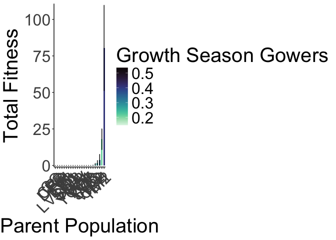

```r
ucd_total_fitness %>%
  group_by(pop, elev_m, GrwSsn_GD_Recent, Wtr_Year_GD_Recent) %>%
  summarise(meanFruits=mean(Total_Fitness, na.rm = TRUE), semFruits=sem(Total_Fitness, na.rm=TRUE)) %>%
  ggplot(aes(x=fct_reorder(pop, meanFruits), y=meanFruits, fill=GrwSsn_GD_Recent)) +
  geom_col(width = 0.7,position = position_dodge(0.75)) +
  geom_errorbar(aes(ymin=meanFruits-semFruits,ymax=meanFruits+semFruits),width=.2, position =
                  position_dodge(0.75)) +
  theme_classic() +
  scale_y_continuous(expand = c(0.01, 0)) +
  labs(y="Total Fitness", x="Parent Population", fill="Growth Season Gowers") +
  scale_fill_viridis(option="mako", direction = -1) +
  theme(text=element_text(size=30), axis.text.x = element_text(angle = 45,  hjust = 1))
```

```
## can override using the `.groups` argument.
```

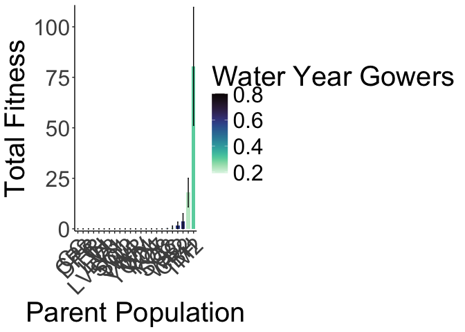

```r
##ggsave("../output/UCD_Traits/UCD_Total_Fitness_GrwSsn_GD_Recent.png", width = 12, height = 8, units = "in")

ucd_total_fitness %>%
  group_by(pop, elev_m, GrwSsn_GD_Recent, Wtr_Year_GD_Recent) %>%
  summarise(meanFruits=mean(Total_Fitness, na.rm = TRUE), semFruits=sem(Total_Fitness, na.rm=TRUE)) %>%
  ggplot(aes(x=fct_reorder(pop, meanFruits), y=meanFruits, fill=Wtr_Year_GD_Recent)) +
  geom_col(width = 0.7,position = position_dodge(0.75)) +
  geom_errorbar(aes(ymin=meanFruits-semFruits,ymax=meanFruits+semFruits),width=.2, position =
                  position_dodge(0.75)) +
  theme_classic() +
  scale_y_continuous(expand = c(0.01, 0)) +
  labs(y="Total Fitness", x="Parent Population", fill="Water Year Gowers") +
  scale_fill_viridis(option="mako", direction = -1) +
  theme(text=element_text(size=30), axis.text.x = element_text(angle = 45,  hjust = 1))
```

```r
##ggsave("../output/UCD_Traits/UCD_Total_Fitness_Wtr_Year_GD_Recent.png", width = 12, height = 8, units = "in")
```

### Scatterplots

```r
#scatter plots
GSCD <- ucd_total_fitness %>%
  group_by(pop, elev_m, GrwSsn_GD_Recent, GrwSsn_GD_Historical) %>%
  summarise(meanEst=mean(Total_Fitness, na.rm = TRUE), semEst=sem(Total_Fitness, na.rm=TRUE)) %>%
  pivot_longer(cols = starts_with("GrwSsn"), names_to = "TimePd", values_to = "GrwSsn_CD") %>%
  mutate(TimePd=str_replace(TimePd, "GrwSsn_GD_", "")) %>%
  ggplot(aes(x=GrwSsn_CD, y=meanEst, color=TimePd, group = pop)) +
  geom_point(size=6, alpha=0.7) +
  geom_errorbar(aes(ymin=meanEst-semEst,ymax=meanEst+semEst),width=.02, linewidth = 2) +
  theme_classic() +
  scale_y_continuous(expand = c(0.01, 0)) +
  labs(y="Total Fitness", x="Growth Season CD", color="Time Period") +
  scale_color_manual(values=timepd_palette) +
  theme(text=element_text(size=30))
```

```
## can override using the `.groups` argument.
```

```r
WYCD <- ucd_total_fitness %>%
  group_by(pop, elev_m, Wtr_Year_GD_Recent, Wtr_Year_GD_Historical) %>%
  summarise(meanEst=mean(Total_Fitness, na.rm = TRUE), semEst=sem(Total_Fitness, na.rm=TRUE)) %>%
  pivot_longer(cols = starts_with("Wtr_Year"), names_to = "TimePd", values_to = "Wtr_Year_CD") %>%
  mutate(TimePd=str_replace(TimePd, "Wtr_Year_GD_", "")) %>%
  ggplot(aes(x=Wtr_Year_CD, y=meanEst, color=TimePd, group = pop)) +
  geom_point(size=6, alpha=0.7) +
  geom_errorbar(aes(ymin=meanEst-semEst,ymax=meanEst+semEst),width=.02, linewidth = 2) +
  theme_classic() +
  scale_y_continuous(expand = c(0.01, 0)) +
  labs(y="Total Fitness", x="Water Year CD", color="Time Period") +
  scale_color_manual(values=timepd_palette) +
  theme(text=element_text(size=30))
```

```
## can override using the `.groups` argument.
```

```r
GD <- ucd_total_fitness %>%
  group_by(pop, elev_m, Geographic_Dist) %>%
  summarise(meanEst=mean(Total_Fitness, na.rm = TRUE), semEst=sem(Total_Fitness, na.rm=TRUE)) %>%
  ggplot(aes(x=Geographic_Dist, y=meanEst, group = pop)) +
  geom_point(size=6) +
  geom_errorbar(aes(ymin=meanEst-semEst,ymax=meanEst+semEst),width=.02, linewidth = 2) +
  theme_classic() +
  scale_y_continuous(expand = c(0.01, 0)) +
  labs(y="Total Fitness", x="Geographic Distance (m)") +
  theme(text=element_text(size=30), axis.text.x = element_text(angle = 45,  hjust = 1))
ED <- ucd_total_fitness %>%
  group_by(pop, elev_m, Elev_Dist) %>%
  summarise(meanEst=mean(Total_Fitness, na.rm = TRUE), semEst=sem(Total_Fitness, na.rm=TRUE)) %>%
  ggplot(aes(x=Elev_Dist, y=meanEst, group = pop)) +
  geom_point(size=6) +
  geom_errorbar(aes(ymin=meanEst-semEst,ymax=meanEst+semEst),width=.02, linewidth = 2) +
  theme_classic() +
  scale_y_continuous(expand = c(0.01, 0)) +
  labs(y="Total Fitness", x="Elevation Distance (m)") +
  theme(text=element_text(size=30))
ucd_total_fitness_FIG <- ggarrange(GSCD, WYCD, GD, ED, ncol=2, nrow=2)
#ggsave("../output/UCD_Traits/UCD_Total_Fitness_SCATTERS.png", width = 24, height = 18, units = "in")
```

## WL2

*Used average Gowers

p(Establishment)*p(Surv to Rep - y1)*Fruits(y1) + p(Winter Surv)*p(Surv to Rep - y2)*Fruits(y2)

```r
wl2_fruits_y1_prep <- wl2_fruits_y1 %>%
  select(block:BedLoc, Genotype:rep, elevation.group:Long, y1_flowers=flowers, y1_fruits=fruits)

winter_surv_prep <- winter_surv %>% select(block:BedLoc, Genotype:Long, WinterSurv)
wl2_surv_to_rep_y2_prep <- wl2_surv_to_rep_y2 %>% select(pop:Long, SurvtoRep_y2)
wl2_fruits_y2_prep <- wl2_fruits_y2 %>%
  select(pop:Genotype, elevation.group:Long, y2_flowers=flowers, y2_fruits=fruits)

wl2_total_fitness <- left_join(wl2_establishment, wl2_surv_to_rep_y1) %>%
  left_join(wl2_fruits_y1_prep) %>%
  left_join(winter_surv_prep) %>%
  left_join(wl2_surv_to_rep_y2_prep) %>%
  left_join(wl2_fruits_y2_prep) %>%
  left_join(wl2_gowers_avg) %>%
  select(block:Wtr_Year_GD_Historical, Geographic_Dist, Elev_Dist, Establishment, SurvtoRep_Y1:y2_fruits) %>%
  mutate(SurvtoRep_Y1=if_else(is.na(SurvtoRep_Y1), 0, SurvtoRep_Y1),
         y1_fruits=if_else(is.na(y1_fruits), 0, y1_fruits),
         y2_fruits=if_else(is.na(y2_fruits), 0, y2_fruits),
         WinterSurv=if_else(is.na(WinterSurv), 0, WinterSurv),
         SurvtoRep_y2=if_else(is.na(SurvtoRep_y2), 0, SurvtoRep_y2)) %>%
  mutate(Total_Fitness=(Establishment*SurvtoRep_Y1*y1_fruits) + (WinterSurv*SurvtoRep_y2*y2_fruits))
```

[output not shown]

```r
wl2_total_fitness %>% group_by(pop) %>% summarise(n=n()) %>% arrange(n)
```

```
## # A tibble: 23 × 2
##    pop       n
##    <chr> <int>
##  1 WV        3
##  2 WR       14
##  3 LV3      27
##  4 SQ1      30
##  5 SQ3      33
##  6 YO4      40
##  7 FR       48
##  8 WL1      48
##  9 SQ2      61
## 10 TM2      84
## # ℹ 13 more rows
```

```r
wl2_total_fitness %>%
  filter(Total_Fitness>0) %>%
  group_by(pop) %>%
  summarise(n=n()) %>%
  arrange(n) #SQ1 and WR only have 1 indiv
```

```
## # A tibble: 9 × 2
##   pop       n
##   <chr> <int>
## 1 SQ1       1
## 2 WR        1
## 3 WL2       5
## 4 CC        9
## 5 SC       10
## 6 IH       13
## 7 YO7      15
## 8 BH       16
## 9 TM2      28
```

```r
unique(wl2_total_fitness$block)
```

```
##  [1] "A" "B" "D" "C" "E" "F" "G" "H" "I" "J" "K" "L" "M"
```

```r
unique(wl2_total_fitness$pop)
```

```
##  [1] "TM2"   "LVTR1" "SQ2"   "YO8"   "CC"    "YO11"  "BH"    "DPR"   "CP2"
## [10] "WL1"   "IH"    "CP3"   "SC"    "FR"    "LV3"   "YO7"   "WV"    "SQ3"
## [19] "WL2"   "LV1"   "YO4"   "WR"    "SQ1"
```

```r
unique(wl2_total_fitness$mf)
```

```
##  [1]  6  7  8  2  5  4  3  1  9 14 13 10 11
```

```r
wl2_total_fitness_sub_dist <- wl2_total_fitness %>%
  select(block:rep, Establishment:Total_Fitness) %>%
  left_join(wl2_sub_dist_avg)
unique(wl2_total_fitness_sub_dist$block)
```

```
##  [1] "A" "B" "D" "C" "E" "F" "G" "H" "I" "J" "K" "L" "M"
```

```r
unique(wl2_total_fitness_sub_dist$pop)
```

```
##  [1] "TM2"   "LVTR1" "SQ2"   "YO8"   "CC"    "YO11"  "BH"    "DPR"   "CP2"
## [10] "WL1"   "IH"    "CP3"   "SC"    "FR"    "LV3"   "YO7"   "WV"    "SQ3"
## [19] "WL2"   "LV1"   "YO4"   "WR"    "SQ1"
```

```r
unique(wl2_total_fitness_sub_dist$mf)
```

```
##  [1]  6  7  8  2  5  4  3  1  9 14 13 10 11
```

### Bar Plots

```
## can override using the `.groups` argument.
```

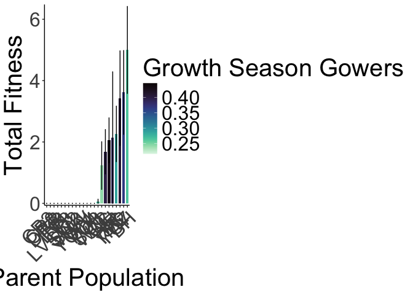

```r
wl2_total_fitness %>%
  group_by(pop, elev_m, GrwSsn_GD_Recent, Wtr_Year_GD_Recent) %>%
  summarise(meanFruits=mean(Total_Fitness, na.rm = TRUE), semFruits=sem(Total_Fitness, na.rm=TRUE)) %>%
  ggplot(aes(x=fct_reorder(pop, meanFruits), y=meanFruits, fill=GrwSsn_GD_Recent)) +
  geom_col(width = 0.7,position = position_dodge(0.75)) +
  geom_errorbar(aes(ymin=meanFruits-semFruits,ymax=meanFruits+semFruits),
                width=.2, position = position_dodge(0.75)) +
  theme_classic() +
  scale_y_continuous(expand = c(0.01, 0)) +
  labs(y="Total Fitness", x="Parent Population", fill="Growth Season Gowers") +
  scale_fill_viridis(option="mako", direction = -1) +
  theme(text=element_text(size=30), axis.text.x = element_text(angle = 45,  hjust = 1))
```

```
## can override using the `.groups` argument.
```

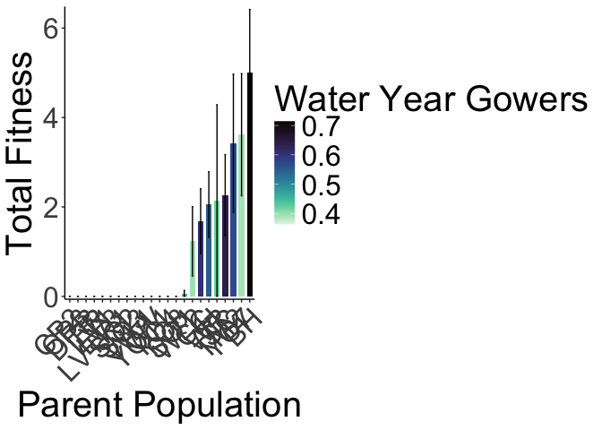

```r
##ggsave("../output/WL2_Traits/WL2_Total_Fitness_GrwSsn_GD_Recent.png", width = 12, height = 8, units = "in")

wl2_total_fitness %>%
  group_by(pop, elev_m, GrwSsn_GD_Recent, Wtr_Year_GD_Recent) %>%
  summarise(meanFruits=mean(Total_Fitness, na.rm = TRUE), semFruits=sem(Total_Fitness, na.rm=TRUE)) %>%
  ggplot(aes(x=fct_reorder(pop, meanFruits), y=meanFruits, fill=Wtr_Year_GD_Recent)) +
  geom_col(width = 0.7,position = position_dodge(0.75)) +
  geom_errorbar(aes(ymin=meanFruits-semFruits,ymax=meanFruits+semFruits),width=.2, position =
                  position_dodge(0.75)) +
  theme_classic() +
  scale_y_continuous(expand = c(0.01, 0)) +
  labs(y="Total Fitness", x="Parent Population", fill="Water Year Gowers") +
  scale_fill_viridis(option="mako", direction = -1) +
  theme(text=element_text(size=30), axis.text.x = element_text(angle = 45,  hjust = 1))
```

```r
##ggsave("../output/WL2_Traits/WL2_Total_Fitness_Wtr_Year_GD_Recent.png", width = 12, height = 8, units = "in")
```

### Scatterplots

```r
#scatter plots
GSCD <- wl2_total_fitness %>%
  group_by(pop, elev_m, GrwSsn_GD_Recent, GrwSsn_GD_Historical) %>%
  summarise(meanEst=mean(Total_Fitness, na.rm = TRUE), semEst=sem(Total_Fitness, na.rm=TRUE)) %>%
  pivot_longer(cols = starts_with("GrwSsn"), names_to = "TimePd", values_to = "GrwSsn_CD") %>%
  mutate(TimePd=str_replace(TimePd, "GrwSsn_GD_", "")) %>%
  ggplot(aes(x=GrwSsn_CD, y=meanEst, color=TimePd, group = pop)) +
  geom_point(size=6) +
  geom_errorbar(aes(ymin=meanEst-semEst,ymax=meanEst+semEst),width=.02, linewidth = 2) +
  theme_classic() +
  scale_y_continuous(expand = c(0.01, 0)) +
  labs(y="Total Fitness", x="Growth Season CD", color="Growth Season \n Climate Distance") +
  scale_color_manual(values=timepd_palette) +
  theme(text=element_text(size=30))
```

```
## can override using the `.groups` argument.
```

```r
WYCD <- wl2_total_fitness %>%
  group_by(pop, elev_m, Wtr_Year_GD_Recent, Wtr_Year_GD_Historical) %>%
  summarise(meanEst=mean(Total_Fitness, na.rm = TRUE), semEst=sem(Total_Fitness, na.rm=TRUE)) %>%
  pivot_longer(cols = starts_with("Wtr_Year"), names_to = "TimePd", values_to = "Wtr_Year_CD") %>%
  mutate(TimePd=str_replace(TimePd, "Wtr_Year_GD_", "")) %>%
  ggplot(aes(x=Wtr_Year_CD, y=meanEst, color=TimePd, group = pop)) +
  geom_point(size=6) +
  geom_errorbar(aes(ymin=meanEst-semEst,ymax=meanEst+semEst),width=.02,linewidth = 2) +
  theme_classic() +
  scale_y_continuous(expand = c(0.01, 0)) +
  labs(y="Total Fitness", x="Water Year CD", color="Water Year \n Climate Distance") +
  scale_color_manual(values=timepd_palette) +
  theme(text=element_text(size=30))
```

```
## can override using the `.groups` argument.
```

```r
GD <- wl2_total_fitness %>%
  group_by(pop, elev_m, GrwSsn_GD_Recent, Wtr_Year_GD_Recent, Geographic_Dist) %>%
  summarise(meanEst=mean(Total_Fitness, na.rm = TRUE), semEst=sem(Total_Fitness, na.rm=TRUE)) %>%
  ggplot(aes(x=Geographic_Dist, y=meanEst, group = pop)) +
  geom_point(size=6) +
  geom_errorbar(aes(ymin=meanEst-semEst,ymax=meanEst+semEst),width=.02, linewidth = 2) +
  theme_classic() +
  scale_y_continuous(expand = c(0.01, 0)) +
  labs(y="Total Fitness", x="Geographic Distance (m)") +
  theme(text=element_text(size=30), axis.text.x = element_text(angle = 45,  hjust = 1))
```

```
## 'Wtr_Year_GD_Recent'. You can override using the `.groups` argument.
```

```r
ED <- wl2_total_fitness %>%
  group_by(pop, elev_m, Elev_Dist) %>%
  summarise(meanEst=mean(Total_Fitness, na.rm = TRUE), semEst=sem(Total_Fitness, na.rm=TRUE)) %>%
  ggplot(aes(x=Elev_Dist, y=meanEst, group = pop)) +
  geom_point(size=6) +
  geom_errorbar(aes(ymin=meanEst-semEst,ymax=meanEst+semEst),width=.02, linewidth = 2) +
  theme_classic() +
  scale_y_continuous(expand = c(0.01, 0)) +
  labs(y="Total Fitness", x="Elevation Distance (m)") +
  theme(text=element_text(size=30))
WL2_total_fitness_FIG <- ggarrange(GSCD, WYCD, GD, ED, ncol=2, nrow=2)
#ggsave("../output/WL2_Traits/WL2_Total_Fitness_SCATTERS.png", width = 24, height = 18, units = "in")
```

## Stats

### Check Distributions

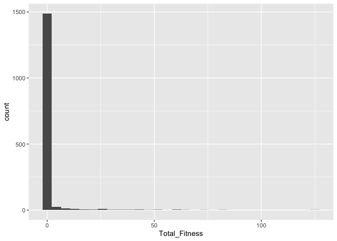

```r
wl2_total_fitness %>%
  ggplot(aes(x=Total_Fitness)) +
  geom_histogram()
```

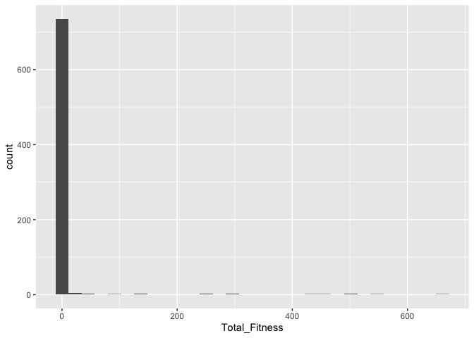

```r
ucd_total_fitness %>%
  ggplot(aes(x=Total_Fitness)) +
  geom_histogram()
```

### Transformations and Scaling

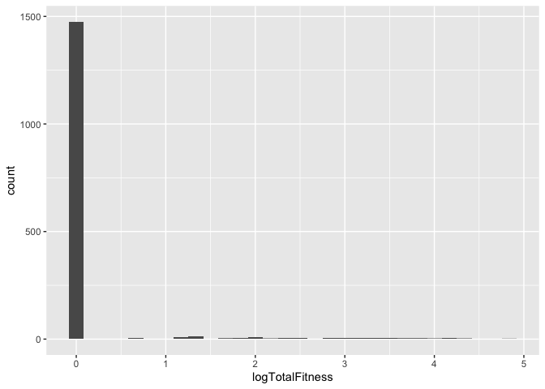

```r
wl2_total_fitness_scaled <- wl2_total_fitness %>%
  mutate_at(c("GrwSsn_GD_Recent","Wtr_Year_GD_Recent",                                                           "GrwSsn_GD_Historical","Wtr_Year_GD_Historical",
              "Geographic_Dist"),scale) %>%
  mutate(logTotalFitness=log(Total_Fitness+1),
         log10TotalFitness=log10(Total_Fitness+1)) #log transformation, add 1 for 0s

wl2_total_fitness_scaled %>% #didn't help much
  ggplot(aes(x=logTotalFitness)) +
  geom_histogram()
```

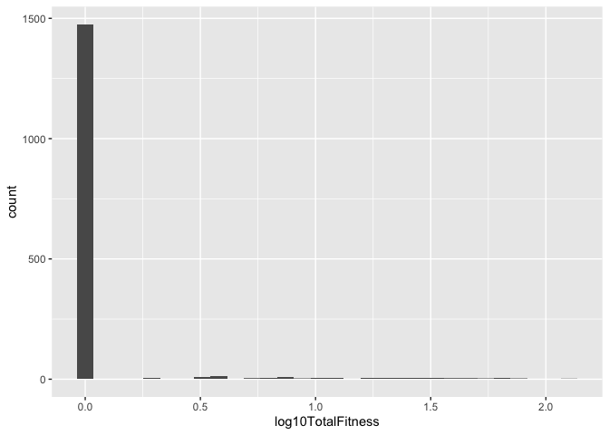

```r
wl2_total_fitness_scaled %>% #didn't help much
  ggplot(aes(x=log10TotalFitness)) +
  geom_histogram()
```

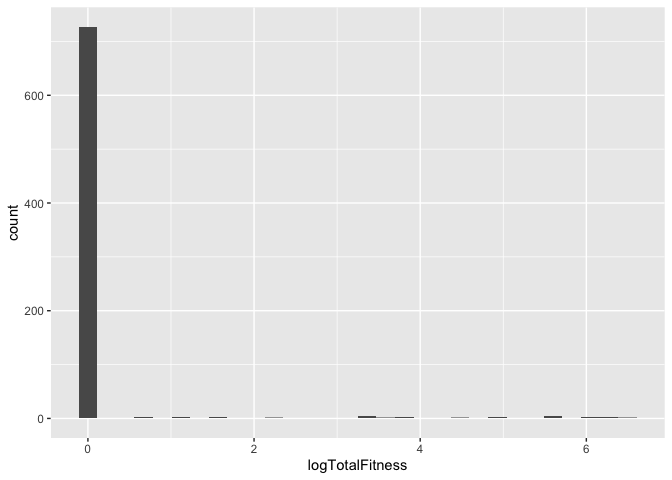

```r
ucd_total_fitness_scaled <- ucd_total_fitness %>%
  mutate_at(c("GrwSsn_GD_Recent","Wtr_Year_GD_Recent",
              "GrwSsn_GD_Historical","Wtr_Year_GD_Historical",
              "Geographic_Dist"), scale) %>%
  mutate(logTotalFitness=log(Total_Fitness+1),
         log10TotalFitness=log10(Total_Fitness+1)) #log transformation, add 1 for 0s

ucd_total_fitness_scaled %>% #didn't help much
  ggplot(aes(x=logTotalFitness)) +
  geom_histogram()
```

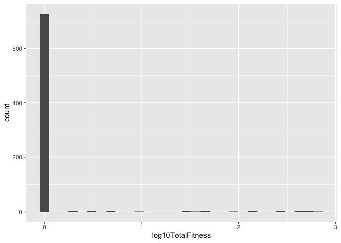

```r
ucd_total_fitness_scaled %>% #didn't help much
  ggplot(aes(x=log10TotalFitness)) +
  geom_histogram()
```

```r
wl2_total_fitness_scaled_sub <- wl2_total_fitness_sub_dist %>%
  mutate_at(c("Wtr_Year_TempDist_Recent",  "Wtr_Year_PPTDist_Recent",
                 "Wtr_Year_TempDist_Historic", "Wtr_Year_PPTDist_Historic",
                 "GrwSsn_TempDist_Recent", "GrwSsn_PPTDist_Recent",
                 "GrwSsn_TempDist_Historic", "GrwSsn_PPTDist_Historic",
              "Geographic_Dist"), scale) %>%
  mutate(logTotalFitness=log(Total_Fitness+1),
         log10TotalFitness=log10(Total_Fitness+1)) #log transformation, add 1 for 0s

ucd_total_fitness_scaled_sub <- ucd_total_fitness_sub_dist %>%
  mutate_at(c("Wtr_Year_TempDist_Recent",  "Wtr_Year_PPTDist_Recent",
                 "Wtr_Year_TempDist_Historic", "Wtr_Year_PPTDist_Historic",
                 "GrwSsn_TempDist_Recent", "GrwSsn_PPTDist_Recent",
                 "GrwSsn_TempDist_Historic", "GrwSsn_PPTDist_Historic",
              "Geographic_Dist"), scale) %>%
  mutate(logTotalFitness=log(Total_Fitness+1),
         log10TotalFitness=log10(Total_Fitness+1)) #log transformation, add 1 for 0s
```

Split total fitness into probability of fitness and total reproductive output since it is so zero inflated.

### Prob of total fitness > 0

#### Calculations

```r
#wl2_total_fitness_scaled %>% filter(is.na(Total_Fitness)) #no NAs
#ucd_total_fitness_scaled  %>% filter(is.na(Total_Fitness)) #no NAs

wl2_prob_fitness <- wl2_total_fitness_scaled %>%
  mutate(ProbFitness=if_else(Total_Fitness==0, 0, 1))

wl2_estab_means <- wl2_prob_fitness %>% # summary for plotting
  group_by(pop) %>%
  summarize(Survival = mean(ProbFitness), n=n()) %>%
  arrange(n)
wl2_estab_means
```

```
## # A tibble: 23 × 3
##    pop   Survival     n
##    <chr>    <dbl> <int>
##  1 WV      0          3
##  2 WR      0.0714    14
##  3 LV3     0         27
##  4 SQ1     0.0333    30
##  5 SQ3     0         33
##  6 YO4     0         40
##  7 FR      0         48
##  8 WL1     0         48
##  9 SQ2     0         61
## 10 TM2     0.333     84
## # ℹ 13 more rows
```

```r
#wl2_prob_fitness %>% group_by(pop, mf, ProbFitness) %>% summarise(n())

wl2_prob_fitness_to_save <- wl2_total_fitness %>%
   mutate(ProbFitness=if_else(Total_Fitness==0, 0, 1)) %>%
  select(block:Elev_Dist, ProbFitness)
#write_csv(wl2_prob_fitness_to_save, "../output/WL2_Traits/WL2_ProbFitness.csv")
```

```r
wl2_prob_fitness_sub <- wl2_total_fitness_scaled_sub %>%
  mutate(ProbFitness=if_else(Total_Fitness==0, 0, 1))
```

```r
ucd_prob_fitness <- ucd_total_fitness_scaled %>%
  filter(pop!="WV") %>% #ONLY 2 INDIVS
  mutate(ProbFitness=if_else(Total_Fitness==0, 0, 1))

ucd_estab_means <- ucd_prob_fitness %>% # summary for plotting
  group_by(pop) %>% #only 2 indivs for WV -remove
  summarize(Survival = mean(ProbFitness),  n=n()) %>%
  arrange(n)
ucd_estab_means
```

```
## # A tibble: 22 × 3
##    pop   Survival     n
##    <chr>    <dbl> <int>
##  1 LV1        0       3
##  2 YO4        0       6
##  3 CP3        0       8
##  4 WR         0       9
##  5 SQ3        0.1    10
##  6 YO8        0      13
##  7 YO11       0      14
##  8 LVTR1      0      15
##  9 YO7        0      17
## 10 DPR        0      22
## # ℹ 12 more rows
```

```r
#ucd_prob_fitness %>% group_by(pop, mf, ProbFitness) %>% summarise(n())

ucd_prob_fitness_to_save <- ucd_total_fitness %>%
  filter(SurvtoRep_Y1==1) %>%
  filter(pop!="WV") %>% #ONLY 2 INDIVS
  mutate(ProbFruits=if_else(Total_Fitness==0, 0, 1))
#write_csv(ucd_prob_fitness_to_save, "../output/UCD_Traits/ProbFruits_UCD.csv")
```

```r
ucd_prob_fitness_sub <- ucd_total_fitness_scaled_sub %>%
  filter(pop!="WV") %>% #ONLY 2 INDIVS
  mutate(ProbFitness=if_else(Total_Fitness==0, 0, 1))
```

#### Plots

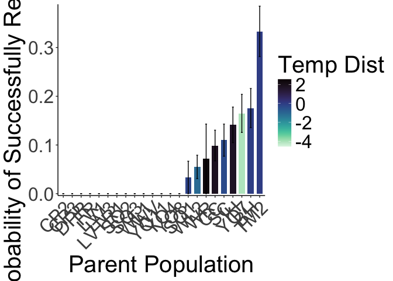

```r
wl2_total_fitness_sub_dist %>%
  mutate(ProbFitness=if_else(Total_Fitness==0, 0, 1)) %>%
  group_by(pop, elev_m, GrwSsn_TempDist_Recent) %>%
  summarise(meanEst=mean(ProbFitness, na.rm = TRUE), semEst=sem(ProbFitness, na.rm=TRUE)) %>%
  filter(!is.na(meanEst)) %>%
  ggplot(aes(x=fct_reorder(pop, meanEst), y=meanEst, fill=GrwSsn_TempDist_Recent)) +
  geom_col(width = 0.7,position = position_dodge(0.75)) +
  geom_errorbar(aes(ymin=meanEst-semEst,ymax=meanEst+semEst),width=.2, position =
                  position_dodge(0.75)) +
  theme_classic() +
  scale_y_continuous(expand = c(0.01, 0)) +
  labs(y="Probability of Successfully Reproducing", x="Parent Population", fill="Temp Dist") +
  scale_fill_viridis(option="mako", direction = -1) +
  theme(text=element_text(size=30), axis.text.x = element_text(angle = 45,  hjust = 1))
```

```r
#scatter plots - recent
GSCD_prob_recent <- wl2_total_fitness %>%
  mutate(ProbFitness=if_else(Total_Fitness==0, 0, 1)) %>%
  group_by(pop, elev_m, GrwSsn_GD_Recent, GrwSsn_GD_Historical) %>%
  summarise(meanEst=mean(ProbFitness, na.rm = TRUE), semEst=sem(ProbFitness, na.rm=TRUE)) %>%
  ggplot(aes(x=GrwSsn_GD_Recent, y=meanEst, group = pop)) +
  geom_point(size=6) +
  geom_errorbar(aes(ymin=meanEst-semEst,ymax=meanEst+semEst),width=.02, linewidth = 2) +
  theme_classic() +
  scale_y_continuous(expand = c(0.01, 0)) +
  labs(y="Probability of Successfully Reproducing", x="Recent Growth Season CD") +
  theme(text=element_text(size=30))
```

```
## can override using the `.groups` argument.
```

```r
WYCD_prob_recent <- wl2_total_fitness %>%
  mutate(ProbFitness=if_else(Total_Fitness==0, 0, 1)) %>%
  group_by(pop, elev_m, Wtr_Year_GD_Recent, Wtr_Year_GD_Historical) %>%
  summarise(meanEst=mean(ProbFitness, na.rm = TRUE), semEst=sem(ProbFitness, na.rm=TRUE)) %>%
  ggplot(aes(x=Wtr_Year_GD_Recent, y=meanEst, group = pop)) +
  geom_point(size=6) +
  geom_errorbar(aes(ymin=meanEst-semEst,ymax=meanEst+semEst),width=.02,linewidth = 2) +
  theme_classic() +
  scale_y_continuous(expand = c(0.01, 0)) +
  labs(y="Probability of Successfully Reproducing", x="Recent Water Year CD") +
  theme(text=element_text(size=30))
```

```
## can override using the `.groups` argument.
```

```r
GD_prob <- wl2_total_fitness %>%
  mutate(ProbFitness=if_else(Total_Fitness==0, 0, 1)) %>%
  group_by(pop, elev_m, GrwSsn_GD_Recent, Wtr_Year_GD_Recent, Geographic_Dist) %>%
  summarise(meanEst=mean(ProbFitness, na.rm = TRUE), semEst=sem(ProbFitness, na.rm=TRUE)) %>%
  ggplot(aes(x=Geographic_Dist, y=meanEst, group = pop)) +
  geom_point(size=6) +
  geom_errorbar(aes(ymin=meanEst-semEst,ymax=meanEst+semEst),width=.02, linewidth = 2) +
  theme_classic() +
  scale_y_continuous(expand = c(0.01, 0)) +
  labs(y="Probability of Successfully Reproducing", x="Geographic Distance (m)") +
  theme(text=element_text(size=30), axis.text.x = element_text(angle = 45,  hjust = 1))
```

```
## 'Wtr_Year_GD_Recent'. You can override using the `.groups` argument.
```

```r
ED_prob <- wl2_total_fitness %>%
  mutate(ProbFitness=if_else(Total_Fitness==0, 0, 1)) %>%
  group_by(pop, elev_m, Elev_Dist) %>%
  summarise(meanEst=mean(ProbFitness, na.rm = TRUE), semEst=sem(ProbFitness, na.rm=TRUE)) %>%
  ggplot(aes(x=Elev_Dist, y=meanEst, group = pop)) +
  geom_point(size=6) +
  geom_errorbar(aes(ymin=meanEst-semEst,ymax=meanEst+semEst),width=.02, linewidth = 2) +
  theme_classic() +
  scale_y_continuous(expand = c(0.01, 0)) +
  labs(y="Probability of Successfully Reproducing", x="Elevation Distance (m)") +
  theme(text=element_text(size=30))
WL2_total_fitness_FIG_prob_recent_recent <- ggarrange(GSCD_prob_recent, WYCD_prob_recent, GD_prob, ED_prob, ncol=2, nrow=2)
##ggsave("../output/WL2_Traits/WL2_ProbFitness_SCATTERS_Recent.png", width = 24, height = 18, units = "in")
```

```r
#scatter plots - historic
GSCD_prob_historic <- wl2_total_fitness %>%
  mutate(ProbFitness=if_else(Total_Fitness==0, 0, 1)) %>%
  group_by(pop, elev_m, GrwSsn_GD_Recent, GrwSsn_GD_Historical) %>%
  summarise(meanEst=mean(ProbFitness, na.rm = TRUE), semEst=sem(ProbFitness, na.rm=TRUE)) %>%
  ggplot(aes(x=GrwSsn_GD_Historical, y=meanEst, group = pop)) +
  geom_point(size=6) +
  geom_errorbar(aes(ymin=meanEst-semEst,ymax=meanEst+semEst),width=.02, linewidth = 2) +
  theme_classic() +
  scale_y_continuous(expand = c(0.01, 0)) +
  labs(y="Probability of Successfully Reproducing", x="Historic Growth Season CD") +
  theme(text=element_text(size=30))
```

```
## can override using the `.groups` argument.
```

```r
WYCD_prob_historic <- wl2_total_fitness %>%
  mutate(ProbFitness=if_else(Total_Fitness==0, 0, 1)) %>%
  group_by(pop, elev_m, Wtr_Year_GD_Recent, Wtr_Year_GD_Historical) %>%
  summarise(meanEst=mean(ProbFitness, na.rm = TRUE), semEst=sem(ProbFitness, na.rm=TRUE)) %>%
  ggplot(aes(x=Wtr_Year_GD_Historical, y=meanEst, group = pop)) +
  geom_point(size=6) +
  geom_errorbar(aes(ymin=meanEst-semEst,ymax=meanEst+semEst),width=.02,linewidth = 2) +
  theme_classic() +
  scale_y_continuous(expand = c(0.01, 0)) +
  labs(y="Probability of Successfully Reproducing", x="Historic Water Year CD") +
  theme(text=element_text(size=30))
```

```
## can override using the `.groups` argument.
```

```r
WL2_total_fitness_FIG_prob_historic_historic <- ggarrange(GSCD_prob_historic, WYCD_prob_historic, GD_prob, ED_prob, ncol=2, nrow=2)
##ggsave("../output/WL2_Traits/WL2_ProbFitness_SCATTERS_Historic.png", width = 24, height = 18, units = "in")
```

```r
#scatter plots - recent
GSCD_prob_recent <- ucd_total_fitness %>%
  filter(pop!="WV") %>% #ONLY 2 INDIVS
  mutate(ProbFitness=if_else(Total_Fitness==0, 0, 1)) %>%
  group_by(pop, elev_m, GrwSsn_GD_Recent, GrwSsn_GD_Historical) %>%
  summarise(meanEst=mean(ProbFitness, na.rm = TRUE), semEst=sem(ProbFitness, na.rm=TRUE)) %>%
  ggplot(aes(x=GrwSsn_GD_Recent, y=meanEst, group = pop)) +
  geom_point(size=6) +
  geom_errorbar(aes(ymin=meanEst-semEst,ymax=meanEst+semEst),width=.02, linewidth = 2) +
  theme_classic() +
  scale_y_continuous(expand = c(0.01, 0)) +
  labs(y="Probability of Successfully Reproducing", x="Recent Growth Season CD") +
  theme(text=element_text(size=30))
```

```
## can override using the `.groups` argument.
```

```r
WYCD_prob_recent <- ucd_total_fitness %>%
  filter(pop!="WV") %>% #ONLY 2 INDIVS
  mutate(ProbFitness=if_else(Total_Fitness==0, 0, 1)) %>%
  group_by(pop, elev_m, Wtr_Year_GD_Recent, Wtr_Year_GD_Historical) %>%
  summarise(meanEst=mean(ProbFitness, na.rm = TRUE), semEst=sem(ProbFitness, na.rm=TRUE)) %>%
  ggplot(aes(x=Wtr_Year_GD_Recent, y=meanEst, group = pop)) +
  geom_point(size=6) +
  geom_errorbar(aes(ymin=meanEst-semEst,ymax=meanEst+semEst),width=.02,linewidth = 2) +
  theme_classic() +
  scale_y_continuous(expand = c(0.01, 0)) +
  labs(y="Probability of Successfully Reproducing", x="Recent Water Year CD") +
  theme(text=element_text(size=30))
```

```
## can override using the `.groups` argument.
```

```r
GD_prob <- ucd_total_fitness %>%
  filter(pop!="WV") %>% #ONLY 2 INDIVS
  mutate(ProbFitness=if_else(Total_Fitness==0, 0, 1)) %>%
  group_by(pop, elev_m, GrwSsn_GD_Recent, Wtr_Year_GD_Recent, Geographic_Dist) %>%
  summarise(meanEst=mean(ProbFitness, na.rm = TRUE), semEst=sem(ProbFitness, na.rm=TRUE)) %>%
  ggplot(aes(x=Geographic_Dist, y=meanEst, group = pop)) +
  geom_point(size=6) +
  geom_errorbar(aes(ymin=meanEst-semEst,ymax=meanEst+semEst),width=.02, linewidth = 2) +
  theme_classic() +
  scale_y_continuous(expand = c(0.01, 0)) +
  labs(y="Probability of Successfully Reproducing", x="Geographic Distance (m)") +
  theme(text=element_text(size=30), axis.text.x = element_text(angle = 45,  hjust = 1))
```

```
## 'Wtr_Year_GD_Recent'. You can override using the `.groups` argument.
```

```r
ED_prob <- ucd_total_fitness %>%
  filter(pop!="WV") %>% #ONLY 2 INDIVS
  mutate(ProbFitness=if_else(Total_Fitness==0, 0, 1)) %>%
  group_by(pop, elev_m, Elev_Dist) %>%
  summarise(meanEst=mean(ProbFitness, na.rm = TRUE), semEst=sem(ProbFitness, na.rm=TRUE)) %>%
  ggplot(aes(x=Elev_Dist, y=meanEst, group = pop)) +
  geom_point(size=6) +
  geom_errorbar(aes(ymin=meanEst-semEst,ymax=meanEst+semEst),width=.02, linewidth = 2) +
  theme_classic() +
  scale_y_continuous(expand = c(0.01, 0)) +
  labs(y="Probability of Successfully Reproducing", x="Elevation Distance (m)") +
  theme(text=element_text(size=30))
UCD_total_fitness_FIG_prob_recent_recent <- ggarrange(GSCD_prob_recent, WYCD_prob_recent, GD_prob, ED_prob, ncol=2, nrow=2)
##ggsave("../output/UCD_Traits/UCD_ProbFitness_SCATTERS_Recent.png", width = 24, height = 18, units = "in")
```

```r
#scatter plots - historic
GSCD_prob_historic <- ucd_total_fitness %>%
  filter(pop!="WV") %>% #ONLY 2 INDIVS
  mutate(ProbFitness=if_else(Total_Fitness==0, 0, 1)) %>%
  group_by(pop, elev_m, GrwSsn_GD_Recent, GrwSsn_GD_Historical) %>%
  summarise(meanEst=mean(ProbFitness, na.rm = TRUE), semEst=sem(ProbFitness, na.rm=TRUE)) %>%
  ggplot(aes(x=GrwSsn_GD_Historical, y=meanEst, group = pop)) +
  geom_point(size=6) +
  geom_errorbar(aes(ymin=meanEst-semEst,ymax=meanEst+semEst),width=.02, linewidth = 2) +
  theme_classic() +
  scale_y_continuous(expand = c(0.01, 0)) +
  labs(y="Probability of Successfully Reproducing", x="Historic Growth Season CD") +
  theme(text=element_text(size=30))
```

```
## can override using the `.groups` argument.
```

```r
WYCD_prob_historic <- ucd_total_fitness %>%
  filter(pop!="WV") %>% #ONLY 2 INDIVS
  mutate(ProbFitness=if_else(Total_Fitness==0, 0, 1)) %>%
  group_by(pop, elev_m, Wtr_Year_GD_Recent, Wtr_Year_GD_Historical) %>%
  summarise(meanEst=mean(ProbFitness, na.rm = TRUE), semEst=sem(ProbFitness, na.rm=TRUE)) %>%
  ggplot(aes(x=Wtr_Year_GD_Historical, y=meanEst, group = pop)) +
  geom_point(size=6) +
  geom_errorbar(aes(ymin=meanEst-semEst,ymax=meanEst+semEst),width=.02,linewidth = 2) +
  theme_classic() +
  scale_y_continuous(expand = c(0.01, 0)) +
  labs(y="Probability of Successfully Reproducing", x="Historic Water Year CD") +
  theme(text=element_text(size=30))
```

```
## can override using the `.groups` argument.
```

```r
UCD_total_fitness_FIG_prob_historic_historic <- ggarrange(GSCD_prob_historic, WYCD_prob_historic, GD_prob, ED_prob, ncol=2, nrow=2)
##ggsave("../output/UCD_Traits/UCD_ProbFitness_SCATTERS_Historic.png", width = 24, height = 18, units = "in")
```

```r
#scatter plots - recent
GSCD_prob_recent <- wl2_total_fitness_sub_dist %>%
  mutate(ProbFitness=if_else(Total_Fitness==0, 0, 1)) %>%
  group_by(pop, elev_m, GrwSsn_TempDist_Recent, GrwSsn_TempDist_Historic) %>%
  summarise(meanEst=mean(ProbFitness, na.rm = TRUE), semEst=sem(ProbFitness, na.rm=TRUE)) %>%
  ggplot(aes(x=GrwSsn_TempDist_Recent, y=meanEst, group = pop)) +
  geom_point(size=6) +
  geom_errorbar(aes(ymin=meanEst-semEst,ymax=meanEst+semEst),width=.3, linewidth = 2) +
  theme_classic() +
  scale_y_continuous(expand = c(0.01, 0)) +
  labs(y="Probability of Successfully Reproducing", x="Recent Growth Season Temp Dist") +
  theme(text=element_text(size=30))
```

```
## You can override using the `.groups` argument.
```

```r
WYCD_prob_recent <- wl2_total_fitness_sub_dist %>%
  mutate(ProbFitness=if_else(Total_Fitness==0, 0, 1)) %>%
  group_by(pop, elev_m, Wtr_Year_TempDist_Recent, Wtr_Year_TempDist_Historic) %>%
  summarise(meanEst=mean(ProbFitness, na.rm = TRUE), semEst=sem(ProbFitness, na.rm=TRUE)) %>%
  ggplot(aes(x=Wtr_Year_TempDist_Recent, y=meanEst, group = pop)) +
  geom_point(size=6) +
  geom_errorbar(aes(ymin=meanEst-semEst,ymax=meanEst+semEst),width=.3,linewidth = 2) +
  theme_classic() +
  scale_y_continuous(expand = c(0.01, 0)) +
  labs(y="Probability of Successfully Reproducing", x="Recent Water Year Temp Dist") +
  theme(text=element_text(size=30))
```

```
## 'Wtr_Year_TempDist_Recent'. You can override using the `.groups` argument.
```

```r
GD_prob <- wl2_total_fitness_sub_dist %>%
  mutate(ProbFitness=if_else(Total_Fitness==0, 0, 1)) %>%
  group_by(pop, elev_m, GrwSsn_TempDist_Recent, Wtr_Year_TempDist_Recent, Geographic_Dist) %>%
  summarise(meanEst=mean(ProbFitness, na.rm = TRUE), semEst=sem(ProbFitness, na.rm=TRUE)) %>%
  ggplot(aes(x=Geographic_Dist, y=meanEst, group = pop)) +
  geom_point(size=6) +
  geom_errorbar(aes(ymin=meanEst-semEst,ymax=meanEst+semEst),width=.2, linewidth = 2) +
  theme_classic() +
  scale_y_continuous(expand = c(0.01, 0)) +
  labs(y="Probability of Successfully Reproducing", x="Geographic Distance (m)") +
  theme(text=element_text(size=30), axis.text.x = element_text(angle = 45,  hjust = 1))
```

```
## 'Wtr_Year_TempDist_Recent'. You can override using the `.groups` argument.
```

```r
ED_prob <- wl2_total_fitness_sub_dist %>%
  mutate(ProbFitness=if_else(Total_Fitness==0, 0, 1)) %>%
  group_by(pop, elev_m, Elev_Dist) %>%
  summarise(meanEst=mean(ProbFitness, na.rm = TRUE), semEst=sem(ProbFitness, na.rm=TRUE)) %>%
  ggplot(aes(x=Elev_Dist, y=meanEst, group = pop)) +
  geom_point(size=6) +
  geom_errorbar(aes(ymin=meanEst-semEst,ymax=meanEst+semEst),width=.3, linewidth = 2) +
  theme_classic() +
  scale_y_continuous(expand = c(0.01, 0)) +
  labs(y="Probability of Successfully Reproducing", x="Elevation Distance (m)") +
  theme(text=element_text(size=30))
WL2_total_fitness_sub_FIG_prob_recent_recent <- ggarrange(GSCD_prob_recent, WYCD_prob_recent, GD_prob, ED_prob, ncol=2, nrow=2)
##ggsave("../output/WL2_Traits/WL2_ProbFitness_TmpSubDist_SCATTERS_Recent.png", width = 24, height = 18, units = "in")
```

```r
#scatter plots - historic
GSCD_prob_historic <- wl2_total_fitness_sub_dist %>%
  mutate(ProbFitness=if_else(Total_Fitness==0, 0, 1)) %>%
  group_by(pop, elev_m, GrwSsn_TempDist_Recent, GrwSsn_TempDist_Historic) %>%
  summarise(meanEst=mean(ProbFitness, na.rm = TRUE), semEst=sem(ProbFitness, na.rm=TRUE)) %>%
  ggplot(aes(x=GrwSsn_TempDist_Historic, y=meanEst, group = pop)) +
  geom_point(size=6) +
  geom_errorbar(aes(ymin=meanEst-semEst,ymax=meanEst+semEst),width=.3, linewidth = 2) +
  theme_classic() +
  scale_y_continuous(expand = c(0.01, 0)) +
  labs(y="Probability of Successfully Reproducing", x="Historic Growth Season Temp Dist") +
  theme(text=element_text(size=30))
```

```
## You can override using the `.groups` argument.
```

```r
WYCD_prob_historic <- wl2_total_fitness_sub_dist %>%
  mutate(ProbFitness=if_else(Total_Fitness==0, 0, 1)) %>%
  group_by(pop, elev_m, Wtr_Year_TempDist_Recent, Wtr_Year_TempDist_Historic) %>%
  summarise(meanEst=mean(ProbFitness, na.rm = TRUE), semEst=sem(ProbFitness, na.rm=TRUE)) %>%
  ggplot(aes(x=Wtr_Year_TempDist_Historic, y=meanEst, group = pop)) +
  geom_point(size=6) +
  geom_errorbar(aes(ymin=meanEst-semEst,ymax=meanEst+semEst),width=.3,linewidth = 2) +
  theme_classic() +
  scale_y_continuous(expand = c(0.01, 0)) +
  labs(y="Probability of Successfully Reproducing", x="Historic Water Year Temp Dist") +
  theme(text=element_text(size=30))
```

```
## 'Wtr_Year_TempDist_Recent'. You can override using the `.groups` argument.
```

```r
WL2_total_fitness_sub_FIG_prob_historic_historic <- ggarrange(GSCD_prob_historic, WYCD_prob_historic, GD_prob, ED_prob, ncol=2, nrow=2)
##ggsave("../output/WL2_Traits/WL2_ProbFitness_TmpSubDist_SCATTERS_Historic.png", width = 24, height = 18, units = "in")
```

```r
#scatter plots - recent
GSCD_prob_recent <- ucd_total_fitness_sub_dist %>%
  filter(pop!="WV") %>% #ONLY 2 INDIVS
  mutate(ProbFitness=if_else(Total_Fitness==0, 0, 1)) %>%
  group_by(pop, elev_m, GrwSsn_TempDist_Recent, GrwSsn_TempDist_Historic) %>%
  summarise(meanEst=mean(ProbFitness, na.rm = TRUE), semEst=sem(ProbFitness, na.rm=TRUE)) %>%
  ggplot(aes(x=GrwSsn_TempDist_Recent, y=meanEst, group = pop)) +
  geom_point(size=6) +
  geom_errorbar(aes(ymin=meanEst-semEst,ymax=meanEst+semEst),width=.3, linewidth = 2) +
  theme_classic() +
  scale_y_continuous(expand = c(0.01, 0)) +
  labs(y="Probability of Successfully Reproducing", x="Recent Growth Season Temp Dist") +
  theme(text=element_text(size=30))
```

```
## You can override using the `.groups` argument.
```

```r
WYCD_prob_recent <- ucd_total_fitness_sub_dist %>%
  filter(pop!="WV") %>% #ONLY 2 INDIVS
  mutate(ProbFitness=if_else(Total_Fitness==0, 0, 1)) %>%
  group_by(pop, elev_m, Wtr_Year_TempDist_Recent, Wtr_Year_TempDist_Historic) %>%
  summarise(meanEst=mean(ProbFitness, na.rm = TRUE), semEst=sem(ProbFitness, na.rm=TRUE)) %>%
  ggplot(aes(x=Wtr_Year_TempDist_Recent, y=meanEst, group = pop)) +
  geom_point(size=6) +
  geom_errorbar(aes(ymin=meanEst-semEst,ymax=meanEst+semEst),width=.3,linewidth = 2) +
  theme_classic() +
  scale_y_continuous(expand = c(0.01, 0)) +
  labs(y="Probability of Successfully Reproducing", x="Recent Water Year Temp Dist") +
  theme(text=element_text(size=30))
```

```
## 'Wtr_Year_TempDist_Recent'. You can override using the `.groups` argument.
```

```r
GD_prob <- ucd_total_fitness_sub_dist %>%
  filter(pop!="WV") %>% #ONLY 2 INDIVS
  mutate(ProbFitness=if_else(Total_Fitness==0, 0, 1)) %>%
  group_by(pop, elev_m, GrwSsn_TempDist_Recent, Wtr_Year_TempDist_Recent, Geographic_Dist) %>%
  summarise(meanEst=mean(ProbFitness, na.rm = TRUE), semEst=sem(ProbFitness, na.rm=TRUE)) %>%
  ggplot(aes(x=Geographic_Dist, y=meanEst, group = pop)) +
  geom_point(size=6) +
  geom_errorbar(aes(ymin=meanEst-semEst,ymax=meanEst+semEst),width=.3, linewidth = 2) +
  theme_classic() +
  scale_y_continuous(expand = c(0.01, 0)) +
  labs(y="Probability of Successfully Reproducing", x="Geographic Distance (m)") +
  theme(text=element_text(size=30), axis.text.x = element_text(angle = 45,  hjust = 1))
```

```
## 'Wtr_Year_TempDist_Recent'. You can override using the `.groups` argument.
```

```r
ED_prob <- ucd_total_fitness_sub_dist %>%
  filter(pop!="WV") %>% #ONLY 2 INDIVS
  mutate(ProbFitness=if_else(Total_Fitness==0, 0, 1)) %>%
  group_by(pop, elev_m, Elev_Dist) %>%
  summarise(meanEst=mean(ProbFitness, na.rm = TRUE), semEst=sem(ProbFitness, na.rm=TRUE)) %>%
  ggplot(aes(x=Elev_Dist, y=meanEst, group = pop)) +
  geom_point(size=6) +
  geom_errorbar(aes(ymin=meanEst-semEst,ymax=meanEst+semEst),width=.3, linewidth = 2) +
  theme_classic() +
  scale_y_continuous(expand = c(0.01, 0)) +
  labs(y="Probability of Successfully Reproducing", x="Elevation Distance (m)") +
  theme(text=element_text(size=30))
UCD_total_fitness_sub_FIG_prob_recent_recent <- ggarrange(GSCD_prob_recent, WYCD_prob_recent, GD_prob, ED_prob, ncol=2, nrow=2)
#ggsave("../output/UCD_Traits/UCD_ProbFitness_TmpSubDist_SCATTERS_Recent.png", width = 24, height = 18, units = "in")
```

```r
#scatter plots - historic
GSCD_prob_historic <- ucd_total_fitness_sub_dist %>%
  filter(pop!="WV") %>% #ONLY 2 INDIVS
  mutate(ProbFitness=if_else(Total_Fitness==0, 0, 1)) %>%
  group_by(pop, elev_m, GrwSsn_TempDist_Recent, GrwSsn_TempDist_Historic) %>%
  summarise(meanEst=mean(ProbFitness, na.rm = TRUE), semEst=sem(ProbFitness, na.rm=TRUE)) %>%
  ggplot(aes(x=GrwSsn_TempDist_Historic, y=meanEst, group = pop)) +
  geom_point(size=6) +
  geom_errorbar(aes(ymin=meanEst-semEst,ymax=meanEst+semEst),width=.3, linewidth = 2) +
  theme_classic() +
  scale_y_continuous(expand = c(0.01, 0)) +
  labs(y="Probability of Successfully Reproducing", x="Historic Growth Season Temp Dist") +
  theme(text=element_text(size=30))
```

```
## You can override using the `.groups` argument.
```

```r
WYCD_prob_historic <- ucd_total_fitness_sub_dist %>%
  filter(pop!="WV") %>% #ONLY 2 INDIVS
  mutate(ProbFitness=if_else(Total_Fitness==0, 0, 1)) %>%
  group_by(pop, elev_m, Wtr_Year_TempDist_Recent, Wtr_Year_TempDist_Historic) %>%
  summarise(meanEst=mean(ProbFitness, na.rm = TRUE), semEst=sem(ProbFitness, na.rm=TRUE)) %>%
  ggplot(aes(x=Wtr_Year_TempDist_Historic, y=meanEst, group = pop)) +
  geom_point(size=6) +
  geom_errorbar(aes(ymin=meanEst-semEst,ymax=meanEst+semEst),width=.3,linewidth = 2) +
  theme_classic() +
  scale_y_continuous(expand = c(0.01, 0)) +
  labs(y="Probability of Successfully Reproducing", x="Historic Water Year Temp Dist") +
  theme(text=element_text(size=30))
```

```
## 'Wtr_Year_TempDist_Recent'. You can override using the `.groups` argument.
```

```r
UCD_total_fitness_sub_FIG_prob_historic_historic <- ggarrange(GSCD_prob_historic, WYCD_prob_historic, GD_prob, ED_prob, ncol=2, nrow=2)
#ggsave("../output/UCD_Traits/UCD_ProbFitness_TmpSubDist_SCATTERS_Historic.png", width = 24, height = 18, units = "in")
```

```r
#scatter plots - recent
GSCD_prob_recent <- wl2_total_fitness_sub_dist %>%
  mutate(ProbFitness=if_else(Total_Fitness==0, 0, 1)) %>%
  group_by(pop, elev_m, GrwSsn_PPTDist_Recent, GrwSsn_PPTDist_Historic) %>%
  summarise(meanEst=mean(ProbFitness, na.rm = TRUE), semEst=sem(ProbFitness, na.rm=TRUE)) %>%
  ggplot(aes(x=GrwSsn_PPTDist_Recent, y=meanEst, group = pop)) +
  geom_point(size=6) +
  geom_errorbar(aes(ymin=meanEst-semEst,ymax=meanEst+semEst),width=0.3, linewidth = 2) +
  theme_classic() +
  scale_y_continuous(expand = c(0.01, 0)) +
  labs(y="Probability of Successfully Reproducing", x="Recent Growth Season PPT Dist") +
  theme(text=element_text(size=30))
```

```
## You can override using the `.groups` argument.
```

```r
WYCD_prob_recent <- wl2_total_fitness_sub_dist %>%
  mutate(ProbFitness=if_else(Total_Fitness==0, 0, 1)) %>%
  group_by(pop, elev_m, Wtr_Year_PPTDist_Recent, Wtr_Year_PPTDist_Historic) %>%
  summarise(meanEst=mean(ProbFitness, na.rm = TRUE), semEst=sem(ProbFitness, na.rm=TRUE)) %>%
  ggplot(aes(x=Wtr_Year_PPTDist_Recent, y=meanEst, group = pop)) +
  geom_point(size=6) +
  geom_errorbar(aes(ymin=meanEst-semEst,ymax=meanEst+semEst),width=.3,linewidth = 2) +
  theme_classic() +
  scale_y_continuous(expand = c(0.01, 0)) +
  labs(y="Probability of Successfully Reproducing", x="Recent Water Year PPT Dist") +
  theme(text=element_text(size=30))
```

```
## You can override using the `.groups` argument.
```

```r
GD_prob <- wl2_total_fitness_sub_dist %>%
  mutate(ProbFitness=if_else(Total_Fitness==0, 0, 1)) %>%
  group_by(pop, elev_m, GrwSsn_PPTDist_Recent, Wtr_Year_PPTDist_Recent, Geographic_Dist) %>%
  summarise(meanEst=mean(ProbFitness, na.rm = TRUE), semEst=sem(ProbFitness, na.rm=TRUE)) %>%
  ggplot(aes(x=Geographic_Dist, y=meanEst, group = pop)) +
  geom_point(size=6) +
  geom_errorbar(aes(ymin=meanEst-semEst,ymax=meanEst+semEst),width=.2, linewidth = 2) +
  theme_classic() +
  scale_y_continuous(expand = c(0.01, 0)) +
  labs(y="Probability of Successfully Reproducing", x="Geographic Distance (m)") +
  theme(text=element_text(size=30), axis.text.x = element_text(angle = 45,  hjust = 1))
```

```
## 'Wtr_Year_PPTDist_Recent'. You can override using the `.groups` argument.
```

```r
ED_prob <- wl2_total_fitness_sub_dist %>%
  mutate(ProbFitness=if_else(Total_Fitness==0, 0, 1)) %>%
  group_by(pop, elev_m, Elev_Dist) %>%
  summarise(meanEst=mean(ProbFitness, na.rm = TRUE), semEst=sem(ProbFitness, na.rm=TRUE)) %>%
  ggplot(aes(x=Elev_Dist, y=meanEst, group = pop)) +
  geom_point(size=6) +
  geom_errorbar(aes(ymin=meanEst-semEst,ymax=meanEst+semEst),width=.3, linewidth = 2) +
  theme_classic() +
  scale_y_continuous(expand = c(0.01, 0)) +
  labs(y="Probability of Successfully Reproducing", x="Elevation Distance (m)") +
  theme(text=element_text(size=30))
WL2_total_fitness_sub_FIG_prob_recent_recent <- ggarrange(GSCD_prob_recent, WYCD_prob_recent, GD_prob, ED_prob, ncol=2, nrow=2)
#ggsave("../output/WL2_Traits/WL2_ProbFitness_PPTSubDist_SCATTERS_Recent.png", width = 24, height = 18, units = "in")
```

```r
#scatter plots - historic
GSCD_prob_historic <- wl2_total_fitness_sub_dist %>%
  mutate(ProbFitness=if_else(Total_Fitness==0, 0, 1)) %>%
  group_by(pop, elev_m, GrwSsn_PPTDist_Recent, GrwSsn_PPTDist_Historic) %>%
  summarise(meanEst=mean(ProbFitness, na.rm = TRUE), semEst=sem(ProbFitness, na.rm=TRUE)) %>%
  ggplot(aes(x=GrwSsn_PPTDist_Historic, y=meanEst, group = pop)) +
  geom_point(size=6) +
  geom_errorbar(aes(ymin=meanEst-semEst,ymax=meanEst+semEst),width=.3, linewidth = 2) +
  theme_classic() +
  scale_y_continuous(expand = c(0.01, 0)) +
  labs(y="Probability of Successfully Reproducing", x="Historic Growth Season PPT Dist") +
  theme(text=element_text(size=30))
```

```
## You can override using the `.groups` argument.
```

```r
WYCD_prob_historic <- wl2_total_fitness_sub_dist %>%
  mutate(ProbFitness=if_else(Total_Fitness==0, 0, 1)) %>%
  group_by(pop, elev_m, Wtr_Year_PPTDist_Recent, Wtr_Year_PPTDist_Historic) %>%
  summarise(meanEst=mean(ProbFitness, na.rm = TRUE), semEst=sem(ProbFitness, na.rm=TRUE)) %>%
  ggplot(aes(x=Wtr_Year_PPTDist_Historic, y=meanEst, group = pop)) +
  geom_point(size=6) +
  geom_errorbar(aes(ymin=meanEst-semEst,ymax=meanEst+semEst),width=.3,linewidth = 2) +
  theme_classic() +
  scale_y_continuous(expand = c(0.01, 0)) +
  labs(y="Probability of Successfully Reproducing", x="Historic Water Year PPT Dist") +
  theme(text=element_text(size=30))
```

```
## You can override using the `.groups` argument.
```

```r
WL2_total_fitness_sub_FIG_prob_historic_historic <- ggarrange(GSCD_prob_historic, WYCD_prob_historic, GD_prob, ED_prob, ncol=2, nrow=2)
#ggsave("../output/WL2_Traits/WL2_ProbFitness_PPTSubDist_SCATTERS_Historic.png", width = 24, height = 18, units = "in")
```

```r
#scatter plots - recent
GSCD_prob_recent <- ucd_total_fitness_sub_dist %>%
  filter(pop!="WV") %>% #ONLY 2 INDIVS
  mutate(ProbFitness=if_else(Total_Fitness==0, 0, 1)) %>%
  group_by(pop, elev_m, GrwSsn_PPTDist_Recent, GrwSsn_PPTDist_Historic) %>%
  summarise(meanEst=mean(ProbFitness, na.rm = TRUE), semEst=sem(ProbFitness, na.rm=TRUE)) %>%
  ggplot(aes(x=GrwSsn_PPTDist_Recent, y=meanEst, group = pop)) +
  geom_point(size=6) +
  geom_errorbar(aes(ymin=meanEst-semEst,ymax=meanEst+semEst),width=.3, linewidth = 2) +
  theme_classic() +
  scale_y_continuous(expand = c(0.01, 0)) +
  labs(y="Probability of Successfully Reproducing", x="Recent Growth Season PPT Dist") +
  theme(text=element_text(size=30))
```

```
## You can override using the `.groups` argument.
```

```r
WYCD_prob_recent <- ucd_total_fitness_sub_dist %>%
  filter(pop!="WV") %>% #ONLY 2 INDIVS
  mutate(ProbFitness=if_else(Total_Fitness==0, 0, 1)) %>%
  group_by(pop, elev_m, Wtr_Year_PPTDist_Recent, Wtr_Year_PPTDist_Historic) %>%
  summarise(meanEst=mean(ProbFitness, na.rm = TRUE), semEst=sem(ProbFitness, na.rm=TRUE)) %>%
  ggplot(aes(x=Wtr_Year_PPTDist_Recent, y=meanEst, group = pop)) +
  geom_point(size=6) +
  geom_errorbar(aes(ymin=meanEst-semEst,ymax=meanEst+semEst),width=.3,linewidth = 2) +
  theme_classic() +
  scale_y_continuous(expand = c(0.01, 0)) +
  labs(y="Probability of Successfully Reproducing", x="Recent Water Year PPT Dist") +
  theme(text=element_text(size=30))
```

```
## You can override using the `.groups` argument.
```

```r
GD_prob <- ucd_total_fitness_sub_dist %>%
  filter(pop!="WV") %>% #ONLY 2 INDIVS
  mutate(ProbFitness=if_else(Total_Fitness==0, 0, 1)) %>%
  group_by(pop, elev_m, GrwSsn_PPTDist_Recent, Wtr_Year_PPTDist_Recent, Geographic_Dist) %>%
  summarise(meanEst=mean(ProbFitness, na.rm = TRUE), semEst=sem(ProbFitness, na.rm=TRUE)) %>%
  ggplot(aes(x=Geographic_Dist, y=meanEst, group = pop)) +
  geom_point(size=6) +
  geom_errorbar(aes(ymin=meanEst-semEst,ymax=meanEst+semEst),width=.3, linewidth = 2) +
  theme_classic() +
  scale_y_continuous(expand = c(0.01, 0)) +
  labs(y="Probability of Successfully Reproducing", x="Geographic Distance (m)") +
  theme(text=element_text(size=30), axis.text.x = element_text(angle = 45,  hjust = 1))
```

```
## 'Wtr_Year_PPTDist_Recent'. You can override using the `.groups` argument.
```

```r
ED_prob <- ucd_total_fitness_sub_dist %>%
  filter(pop!="WV") %>% #ONLY 2 INDIVS
  mutate(ProbFitness=if_else(Total_Fitness==0, 0, 1)) %>%
  group_by(pop, elev_m, Elev_Dist) %>%
  summarise(meanEst=mean(ProbFitness, na.rm = TRUE), semEst=sem(ProbFitness, na.rm=TRUE)) %>%
  ggplot(aes(x=Elev_Dist, y=meanEst, group = pop)) +
  geom_point(size=6) +
  geom_errorbar(aes(ymin=meanEst-semEst,ymax=meanEst+semEst),width=.3, linewidth = 2) +
  theme_classic() +
  scale_y_continuous(expand = c(0.01, 0)) +
  labs(y="Probability of Successfully Reproducing", x="Elevation Distance (m)") +
  theme(text=element_text(size=30))
UCD_total_fitness_sub_FIG_prob_recent_recent <- ggarrange(GSCD_prob_recent, WYCD_prob_recent, GD_prob, ED_prob, ncol=2, nrow=2)
#ggsave("../output/UCD_Traits/UCD_ProbFitness_PPTSubDist_SCATTERS_Recent.png", width = 24, height = 18, units = "in")
```

```r
#scatter plots - historic
GSCD_prob_historic <- ucd_total_fitness_sub_dist %>%
  filter(pop!="WV") %>% #ONLY 2 INDIVS
  mutate(ProbFitness=if_else(Total_Fitness==0, 0, 1)) %>%
  group_by(pop, elev_m, GrwSsn_PPTDist_Recent, GrwSsn_PPTDist_Historic) %>%
  summarise(meanEst=mean(ProbFitness, na.rm = TRUE), semEst=sem(ProbFitness, na.rm=TRUE)) %>%
  ggplot(aes(x=GrwSsn_PPTDist_Historic, y=meanEst, group = pop)) +
  geom_point(size=6) +
  geom_errorbar(aes(ymin=meanEst-semEst,ymax=meanEst+semEst),width=.3, linewidth = 2) +
  theme_classic() +
  scale_y_continuous(expand = c(0.01, 0)) +
  labs(y="Probability of Successfully Reproducing", x="Historic Growth Season PPT Dist") +
  theme(text=element_text(size=30))
```

```
## You can override using the `.groups` argument.
```

```r
WYCD_prob_historic <- ucd_total_fitness_sub_dist %>%
  filter(pop!="WV") %>% #ONLY 2 INDIVS
  mutate(ProbFitness=if_else(Total_Fitness==0, 0, 1)) %>%
  group_by(pop, elev_m, Wtr_Year_PPTDist_Recent, Wtr_Year_PPTDist_Historic) %>%
  summarise(meanEst=mean(ProbFitness, na.rm = TRUE), semEst=sem(ProbFitness, na.rm=TRUE)) %>%
  ggplot(aes(x=Wtr_Year_PPTDist_Historic, y=meanEst, group = pop)) +
  geom_point(size=6) +
  geom_errorbar(aes(ymin=meanEst-semEst,ymax=meanEst+semEst),width=.3,linewidth = 2) +
  theme_classic() +
  scale_y_continuous(expand = c(0.01, 0)) +
  labs(y="Probability of Successfully Reproducing", x="Historic Water Year PPT Dist") +
  theme(text=element_text(size=30))
```

```
## You can override using the `.groups` argument.
```

```r
UCD_total_fitness_sub_FIG_prob_historic_historic <- ggarrange(GSCD_prob_historic, WYCD_prob_historic, GD_prob, ED_prob, ncol=2, nrow=2)
#ggsave("../output/UCD_Traits/UCD_ProbFitness_PPTSubDist_SCATTERS_Historic.png", width = 24, height = 18, units = "in")
```

#### Figures for paper

```r
prob_fitness_summary <- wl2_total_fitness %>%
  mutate(ProbFitness=if_else(Total_Fitness==0, 0, 1)) %>%
  group_by(pop, elev_m, Geographic_Dist, Wtr_Year_GD_Recent) %>%
  summarise(meanEst=mean(ProbFitness, na.rm = TRUE), semEst=sem(ProbFitness, na.rm=TRUE)) %>%
  mutate(RepYear=if_else(meanEst==0, "None",
                         if_else(pop=="TM2", "Both Years", "Year 2 Only")))
prob_fitness_summary$RepYear <- factor(prob_fitness_summary$RepYear,
                                               levels = c('None','Year 2 Only', 'Both Years'))

prob_fitness_summary_sub <- wl2_total_fitness_sub_dist %>%
  mutate(ProbFitness=if_else(Total_Fitness==0, 0, 1)) %>%
  group_by(pop, elev_m, Wtr_Year_TempDist_Recent, Wtr_Year_PPTDist_Recent) %>%
  summarise(meanEst=mean(ProbFitness, na.rm = TRUE), semEst=sem(ProbFitness, na.rm=TRUE)) %>%
  mutate(RepYear=if_else(meanEst==0, "None",
                         if_else(pop=="TM2", "Both Years", "Year 2 Only")))
```

```
## 'Wtr_Year_TempDist_Recent'. You can override using the `.groups` argument.
```

```r
prob_fitness_summary_sub$RepYear <- factor(prob_fitness_summary_sub$RepYear,
                                               levels = c('None','Year 2 Only', 'Both Years'))

GD_prob <- prob_fitness_summary %>%
  ggplot(aes(x=Geographic_Dist, y=meanEst, group = pop, color=elev_m)) +
  scale_colour_gradient(low = "#F5A540", high = "#0043F0") +
  geom_point(aes(shape=RepYear), size=6) +
  geom_errorbar(aes(ymin=meanEst-semEst,ymax=meanEst+semEst),width=.2, linewidth = 2) +
  annotate("text", x = 136.2622, y= 0.095, label = "WL2",
           colour = "purple", fontface="bold", size = 22 / .pt) +
  theme_classic() +
  scale_y_continuous(expand = c(0.01, 0)) +
  labs(y="Probability of \n Successfully Reproducing", x="Geographic Distance (m)",
       color="Elevation (m)", shape="Rep Year(s)") +
  theme(text=element_text(size=30), axis.text.x = element_text(angle = 45,  hjust = 1))

WYCD_prob_recent <- prob_fitness_summary %>%
  ggplot(aes(x=Wtr_Year_GD_Recent, y=meanEst, group = pop, color=elev_m)) +
  scale_colour_gradient(low = "#F5A540", high = "#0043F0") +
  geom_point(aes(shape=RepYear), size=6) +
  geom_errorbar(aes(ymin=meanEst-semEst,ymax=meanEst+semEst),width=.02,linewidth = 2) +
  annotate("text", x = 0.3959884, y= 0.095, label = "WL2",
           colour = "purple", fontface="bold", size = 22 / .pt) +
  theme_classic() +
  scale_y_continuous(expand = c(0.01, 0)) +
  labs(y="Probability of \n Successfully Reproducing", x="Recent Water Year Climate Dist",
       color="Elevation (m)", shape="Rep Year(s)") +
  theme(text=element_text(size=30))

WYtemp_prob_recent <- prob_fitness_summary_sub %>%
  ggplot(aes(x=Wtr_Year_TempDist_Recent, y=meanEst, group = pop, color=elev_m)) +
  scale_colour_gradient(low = "#F5A540", high = "#0043F0") +
  geom_point(aes(shape=RepYear), size=6) +
  geom_errorbar(aes(ymin=meanEst-semEst,ymax=meanEst+semEst),width=.3,linewidth = 2) +
  annotate("text", x = 0.6300972    , y= 0.095, label = "WL2",
           colour = "purple", fontface="bold", size = 22 / .pt) +
  theme_classic() +
  scale_y_continuous(expand = c(0.01, 0)) +
  labs(y="Probability of \n Successfully Reproducing", x="Recent Water Year Temp Dist (°C)",
       color="Elevation (m)", shape="Rep Year(s)") +
  theme(text=element_text(size=30))

WYppt_prob_recent <- prob_fitness_summary_sub %>%
  ggplot(aes(x=Wtr_Year_PPTDist_Recent, y=meanEst, group = pop, color=elev_m)) +
  scale_colour_gradient(low = "#F5A540", high = "#0043F0") +
  geom_point(aes(shape=RepYear), size=6) +
  geom_errorbar(aes(ymin=meanEst-semEst,ymax=meanEst+semEst),width=.3,linewidth = 2) +
  annotate("text", x = -546.96536, y= 0.095, label = "WL2",
           colour = "purple", fontface="bold", size = 22 / .pt) +
  theme_classic() +
  scale_y_continuous(expand = c(0.01, 0)) +
  labs(y="Probability of \n Successfully Reproducing", x="Recent Water Year PPT Dist (mm)",
       color="Elevation (m)", shape="Rep Year(s)") +
  theme(text=element_text(size=30))

WL2_prob_fitness_for_paper <- ggarrange(GD_prob, WYCD_prob_recent,
                                        WYtemp_prob_recent, WYppt_prob_recent,
                                        labels = c("A)", "B)", "C)", "D)"),
                                        font.label = list(size=30, face = "plain"),
                                        ncol=2, nrow=2)
#ggsave("../output/WL2_Traits/WL2_ProbFitness_SCATTERS_Summary_Recent_2324.png", width = 26, height = 18, units = "in")
```

```r
prob_fitness_summary_sub_grw <- wl2_total_fitness_sub_dist %>%
  mutate(ProbFitness=if_else(Total_Fitness==0, 0, 1)) %>%
  group_by(pop, elev_m, GrwSsn_PPTDist_Recent, GrwSsn_PPTDist_Historic) %>%
  summarise(meanEst=mean(ProbFitness, na.rm = TRUE), semEst=sem(ProbFitness, na.rm=TRUE)) %>%
  mutate(RepYear=if_else(meanEst==0, "None",
                         if_else(pop=="TM2", "Both Years", "Year 2 Only")))
```

```
## You can override using the `.groups` argument.
```

```r
prob_fitness_summary_sub_grw$RepYear <- factor(prob_fitness_summary_sub_grw$RepYear,
                                               levels = c('None','Year 2 Only', 'Both Years'))

GSCD_prob_recent <- prob_fitness_summary_sub_grw %>%
  ggplot(aes(x=GrwSsn_PPTDist_Recent, y=meanEst, group = pop, color=elev_m)) +
  scale_colour_gradient(low = "#F5A540", high = "#0043F0") +
  geom_point(aes(shape=RepYear), size=6) +
  geom_errorbar(aes(ymin=meanEst-semEst,ymax=meanEst+semEst),width=0.3, linewidth = 2) +
  annotate("text", x = 197.24399, y= 0.095, label = "WL2",
           colour = "purple", fontface="bold", size = 22 / .pt) +
  theme_classic() +
  scale_y_continuous(expand = c(0.01, 0)) +
  labs(y="Probability of Successfully Reproducing", x="Recent Growth Season PPT Dist",
       color="Elevation (m)", shape="Rep Year(s)") +
  theme(text=element_text(size=30))

GSCD_prob_historic <- prob_fitness_summary_sub_grw %>%
  ggplot(aes(x=GrwSsn_PPTDist_Historic, y=meanEst, group = pop, color=elev_m)) +
  scale_colour_gradient(low = "#F5A540", high = "#0043F0") +
  geom_point(aes(shape=RepYear), size=6) +
  geom_errorbar(aes(ymin=meanEst-semEst,ymax=meanEst+semEst),width=.3, linewidth = 2) +
  annotate("text", x = 250.881330, y= 0.095, label = "WL2",
           colour = "purple", fontface="bold", size = 22 / .pt) +
  theme_classic() +
  scale_y_continuous(expand = c(0.01, 0)) +
  labs(y="Probability of Successfully Reproducing", x="Historic Growth Season PPT Dist",
       color="Elevation (m)", shape="Rep Year(s)") +
  theme(text=element_text(size=30))

WL2_prob_fitness_for_paper2 <- ggarrange(GSCD_prob_historic,
                                         GSCD_prob_recent,
                                        ncol=2, nrow=1)
#ggsave("../output/WL2_Traits/WL2_ProbFitness_SCATTERS_PPT_GRWSSN_2324.png", width = 26, height = 9, units = "in")
```

### Check CWD Dist

```
## You can override using the `.groups` argument.
```

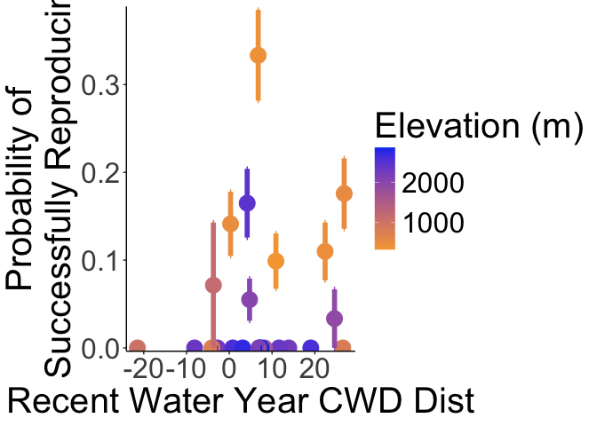

```r
wl2_total_fitness_sub_dist %>%
  mutate(ProbFitness=if_else(Total_Fitness==0, 0, 1)) %>%
  group_by(pop, elev_m, Wtr_Year_CWDDist_Recent, Wtr_Year_CWDDist_Historic) %>%
  summarise(meanEst=mean(ProbFitness, na.rm = TRUE), semEst=sem(ProbFitness, na.rm=TRUE)) %>%
  ggplot(aes(x=Wtr_Year_CWDDist_Recent, y=meanEst, group = pop, color=elev_m)) +
  scale_colour_gradient(low = "#F5A540", high = "#0043F0") +
  geom_point(size=6) +
  geom_errorbar(aes(ymin=meanEst-semEst,ymax=meanEst+semEst),width=.3,linewidth = 2) +
  #annotate("text", x = 12.1639444  , y= 0.65, label = "WL2",
   #       colour = "purple", fontface="bold", size = 22 / .pt) +
  theme_classic() +
  scale_y_continuous(expand = c(0.01, 0)) +
  labs(y="Probability of  \n Successfully Reproducing", x="Recent Water Year CWD Dist",
       color="Elevation (m)") +
  theme(text=element_text(size=30))
```

```
## You can override using the `.groups` argument.
```

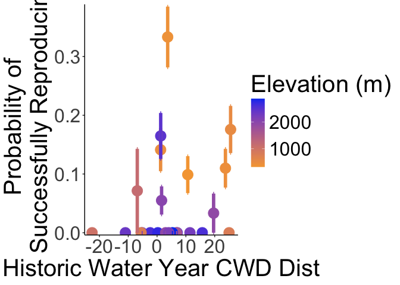

```r
wl2_total_fitness_sub_dist %>%
  mutate(ProbFitness=if_else(Total_Fitness==0, 0, 1)) %>%
  group_by(pop, elev_m, Wtr_Year_CWDDist_Recent, Wtr_Year_CWDDist_Historic) %>%
  summarise(meanEst=mean(ProbFitness, na.rm = TRUE), semEst=sem(ProbFitness, na.rm=TRUE)) %>%
  ggplot(aes(x=Wtr_Year_CWDDist_Historic, y=meanEst, group = pop, color=elev_m)) +
  scale_colour_gradient(low = "#F5A540", high = "#0043F0") +
  geom_point(size=6) +
  geom_errorbar(aes(ymin=meanEst-semEst,ymax=meanEst+semEst),width=.3,linewidth = 2) +
  #annotate("text", x = 8.9845278       , y= 0.65, label = "WL2",
   #       colour = "purple", fontface="bold", size = 22 / .pt) +
  theme_classic() +
  scale_y_continuous(expand = c(0.01, 0)) +
  labs(y="Probability of  \n Successfully Reproducing", x="Historic Water Year CWD Dist",
       color="Elevation (m)") +
  theme(text=element_text(size=30))
```

```
## You can override using the `.groups` argument.
```

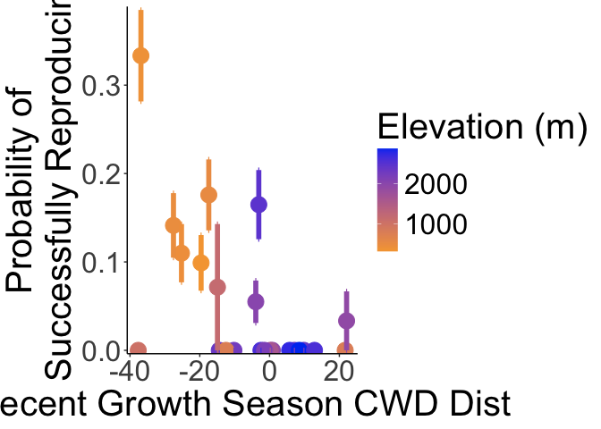

```r
wl2_total_fitness_sub_dist %>%
  mutate(ProbFitness=if_else(Total_Fitness==0, 0, 1)) %>%
  group_by(pop, elev_m, GrwSsn_CWDDist_Recent, GrwSsn_CWDDist_Historic) %>%
  summarise(meanEst=mean(ProbFitness, na.rm = TRUE), semEst=sem(ProbFitness, na.rm=TRUE)) %>%
  ggplot(aes(x=GrwSsn_CWDDist_Recent, y=meanEst, group = pop, color=elev_m)) +
  scale_colour_gradient(low = "#F5A540", high = "#0043F0") +
  geom_point(size=6) +
  geom_errorbar(aes(ymin=meanEst-semEst,ymax=meanEst+semEst),width=.3,linewidth = 2) +
  #annotate("text", x = 12.1639444  , y= 0.65, label = "WL2",
   #       colour = "purple", fontface="bold", size = 22 / .pt) +
  theme_classic() +
  scale_y_continuous(expand = c(0.01, 0)) +
  labs(y="Probability of  \n Successfully Reproducing", x="Recent Growth Season CWD Dist",
       color="Elevation (m)") +
  theme(text=element_text(size=30))
```

```
## You can override using the `.groups` argument.
```

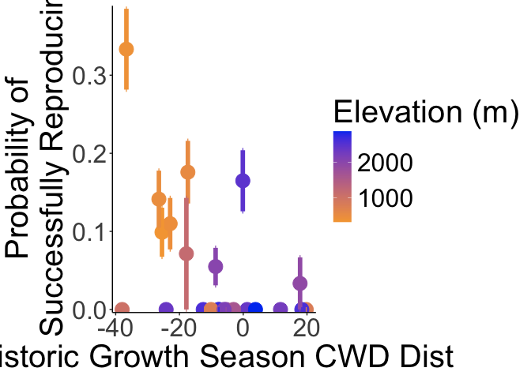

```r
wl2_total_fitness_sub_dist %>%
  mutate(ProbFitness=if_else(Total_Fitness==0, 0, 1)) %>%
  group_by(pop, elev_m, GrwSsn_CWDDist_Recent, GrwSsn_CWDDist_Historic) %>%
  summarise(meanEst=mean(ProbFitness, na.rm = TRUE), semEst=sem(ProbFitness, na.rm=TRUE)) %>%
  ggplot(aes(x=GrwSsn_CWDDist_Historic, y=meanEst, group = pop, color=elev_m)) +
  scale_colour_gradient(low = "#F5A540", high = "#0043F0") +
  geom_point(size=6) +
  geom_errorbar(aes(ymin=meanEst-semEst,ymax=meanEst+semEst),width=.3,linewidth = 2) +
  #annotate("text", x = 8.9845278       , y= 0.65, label = "WL2",
   #       colour = "purple", fontface="bold", size = 22 / .pt) +
  theme_classic() +
  scale_y_continuous(expand = c(0.01, 0)) +
  labs(y="Probability of  \n Successfully Reproducing", x="Historic Growth Season CWD Dist",
       color="Elevation (m)") +
  theme(text=element_text(size=30))
```

### Check for adaptational lag of WL2 pop

T-test compare WL2 to the pop that performed the best?

```r
wl2_total_fitness_sub_dist %>%
  mutate(ProbFitness=if_else(Total_Fitness==0, 0, 1)) %>%
  group_by(pop, elev_m, Wtr_Year_CWDDist_Recent, Wtr_Year_CWDDist_Historic) %>%
  summarise(meanEst=mean(ProbFitness, na.rm = TRUE), semEst=sem(ProbFitness, na.rm=TRUE)) %>%
  arrange(meanEst)
```

```
## You can override using the `.groups` argument.
```

```
## # A tibble: 23 × 6
## # Groups:   pop, elev_m, Wtr_Year_CWDDist_Recent [23]
##    pop   elev_m Wtr_Year_CWDDist_Recent Wtr_Year_CWDDist_Historic meanEst semEst
##    <chr>  <dbl>                   <dbl>                     <dbl>   <dbl>  <dbl>
##  1 CP2    2244.                  13.9                      11.4         0      0
##  2 CP3    2266.                  -2.78                     -5.20        0      0
##  3 DPR    1019.                 -21.5                     -22.5         0      0
##  4 FR      787                   26.5                      25.0         0      0
##  5 LV1    2593.                   0.822                    -2.39        0      0
##  6 LV3    2354.                  -8.12                    -11.0         0      0
##  7 LVTR1  2741.                   3.13                      0.254       0      0
##  8 SQ2    1934.                   7.03                      2.97        0      0
##  9 SQ3    2373.                  11.6                       6.99        0      0
## 10 WL1    1614.                   8.22                      6.73        0      0
## # ℹ 13 more rows
```

```r
wl2_prob_fitness_adapt <- wl2_prob_fitness_to_save %>% filter(pop=="WL2" | pop=="TM2")

adaptlagm1 <- glmer(ProbFitness ~ pop + (1|block), data=wl2_prob_fitness_adapt, family = binomial)
summary(adaptlagm1) #WL2 sig < than TM2
```

```
## Generalized linear mixed model fit by maximum likelihood (Laplace
##   Approximation) [glmerMod]
##  Family: binomial  ( logit )
## Formula: ProbFitness ~ pop + (1 | block)
##    Data: wl2_prob_fitness_adapt
##
##      AIC      BIC   logLik deviance df.resid
##    146.5    156.0    -70.2    140.5      172
##
## Scaled residuals:
##     Min      1Q  Median      3Q     Max
## -1.1382 -0.4025 -0.2346 -0.1210  4.5833
##
## Random effects:
##  Groups Name        Variance Std.Dev.
##  block  (Intercept) 1.017    1.009
## Number of obs: 175, groups:  block, 13
##
## Fixed effects:
##             Estimate Std. Error z value Pr(>|z|)
## (Intercept)  -0.8663     0.4005  -2.163   0.0305 *
## popWL2       -2.4038     0.5534  -4.344  1.4e-05 ***
## ---
## Signif. codes:  0 '***' 0.001 '**' 0.01 '*' 0.05 '.' 0.1 ' ' 1
##
## Correlation of Fixed Effects:
##        (Intr)
## popWL2 -0.208
```

#### Attempt at calculating mean and standard error in logit scale

Get Block means

```r
##block summary
wl2_prob_fit_block_summary <- wl2_total_fitness %>%
  mutate(ProbFitness=if_else(Total_Fitness==0, 0, 1)) %>%
  group_by(pop, block, Geographic_Dist,
           Wtr_Year_GD_Recent, Wtr_Year_GD_Historical, GrwSsn_GD_Recent, GrwSsn_GD_Historical) %>%
  summarise(meanProbBlock=mean(ProbFitness, na.rm = TRUE), n=n())
```

```
## 'Wtr_Year_GD_Recent', 'Wtr_Year_GD_Historical', 'GrwSsn_GD_Recent'. You can
```

```r
#double check this mostly matches getting means across blocks
wl2_prob_fit_block_summary %>% group_by(pop, Geographic_Dist) %>%
  summarise(meanProb=mean(meanProbBlock, na.rm = TRUE),
            semProb=sem(meanProbBlock,  na.rm=TRUE))
```

```
## argument.
```

```
## # A tibble: 23 × 4
## # Groups:   pop [23]
##    pop   Geographic_Dist meanProb semProb
##    <chr>           <dbl>    <dbl>   <dbl>
##  1 BH            159626.   0.176   0.0540
##  2 CC            132498.   0.0989  0.0298
##  3 CP2            21060.   0       0
##  4 CP3            19415.   0       0
##  5 DPR            66246.   0       0
##  6 FR            154694.   0       0
##  7 IH             65203.   0.143   0.0458
##  8 LV1           212682.   0       0
##  9 LV3           213902.   0       0
## 10 LVTR1         213038.   0       0
## # ℹ 13 more rows
```

```r
wl2_total_fitness %>%
  mutate(ProbFitness=if_else(Total_Fitness==0, 0, 1)) %>%
  group_by(pop, Geographic_Dist) %>%
  summarise(meanProb=mean(ProbFitness, na.rm = TRUE),
            semProb=sem(ProbFitness,  na.rm=TRUE))
```

```
## argument.
```

```
## # A tibble: 23 × 4
## # Groups:   pop [23]
##    pop   Geographic_Dist meanProb semProb
##    <chr>           <dbl>    <dbl>   <dbl>
##  1 BH            159626.   0.176   0.0401
##  2 CC            132498.   0.0989  0.0315
##  3 CP2            21060.   0       0
##  4 CP3            19415.   0       0
##  5 DPR            66246.   0       0
##  6 FR            154694.   0       0
##  7 IH             65203.   0.141   0.0365
##  8 LV1           212682.   0       0
##  9 LV3           213902.   0       0
## 10 LVTR1         213038.   0       0
## # ℹ 13 more rows
```

Use Car::loigt and Jenny’s inv.logit function

```r
#check back transformation works
wl2_prob_fit_block_summary %>%
  mutate(logitBlockMean=car::logit(meanProbBlock, adjust = 0.025)) %>%
  mutate(BTlogit=inv.logit(logitBlockMean, a=0.025))
```

```
## # A tibble: 288 × 11
## # Groups:   pop, block, Geographic_Dist, Wtr_Year_GD_Recent,
## #   Wtr_Year_GD_Historical, GrwSsn_GD_Recent [288]
##    pop   block Geographic_Dist Wtr_Year_GD_Recent Wtr_Year_GD_Historical
##    <chr> <chr>           <dbl>              <dbl>                  <dbl>
##  1 BH    A             159626.              0.714                  0.647
##  2 BH    B             159626.              0.714                  0.647
##  3 BH    C             159626.              0.714                  0.647
##  4 BH    D             159626.              0.714                  0.647
##  5 BH    E             159626.              0.714                  0.647
##  6 BH    F             159626.              0.714                  0.647
##  7 BH    G             159626.              0.714                  0.647
##  8 BH    H             159626.              0.714                  0.647
##  9 BH    I             159626.              0.714                  0.647
## 10 BH    J             159626.              0.714                  0.647
## # ℹ 278 more rows
## # ℹ 6 more variables: GrwSsn_GD_Recent <dbl>, GrwSsn_GD_Historical <dbl>,
## #   meanProbBlock <dbl>, n <int>, logitBlockMean <dbl>, BTlogit <dbl>
```

```r
#check back transformation of means
wl2_prob_fit_block_summary %>%
  mutate(logitBlockMean=car::logit(meanProbBlock, adjust = 0.025)) %>%
  ungroup() %>%
  group_by(pop, Geographic_Dist,
           Wtr_Year_GD_Recent, Wtr_Year_GD_Historical,
           GrwSsn_GD_Recent, GrwSsn_GD_Historical) %>%
  summarise(meanProb=mean(meanProbBlock, na.rm=TRUE),
            semProb=sem(meanProbBlock, na.rm=TRUE),
            meanLogit=mean(logitBlockMean, na.rm=TRUE),
            semLogit=sem(logitBlockMean, na.rm=TRUE)) %>%
  mutate(Btmean=inv.logit(meanLogit, a=0.025)) #much smaller values than meanProb...
```

```
## 'Wtr_Year_GD_Recent', 'Wtr_Year_GD_Historical', 'GrwSsn_GD_Recent'. You can
```

```
## # A tibble: 23 × 11
## # Groups:   pop, Geographic_Dist, Wtr_Year_GD_Recent, Wtr_Year_GD_Historical,
## #   GrwSsn_GD_Recent [23]
##    pop   Geographic_Dist Wtr_Year_GD_Recent Wtr_Year_GD_Historical
##    <chr>           <dbl>              <dbl>                  <dbl>
##  1 BH            159626.              0.714                  0.647
##  2 CC            132498.              0.606                  0.569
##  3 CP2            21060.              0.387                  0.437
##  4 CP3            19415.              0.364                  0.423
##  5 DPR            66246.              0.468                  0.457
##  6 FR            154694.              0.559                  0.554
##  7 IH             65203.              0.551                  0.530
##  8 LV1           212682.              0.378                  0.463
##  9 LV3           213902.              0.373                  0.466
## 10 LVTR1         213038.              0.385                  0.465
## # ℹ 13 more rows
## # ℹ 7 more variables: GrwSsn_GD_Recent <dbl>, GrwSsn_GD_Historical <dbl>,
## #   meanProb <dbl>, semProb <dbl>, meanLogit <dbl>, semLogit <dbl>,
## #   Btmean <dbl>
```

```r
#try without 0s and 1s
wl2_logit_compare2 <- wl2_prob_fit_block_summary %>%
  filter(meanProbBlock>0, meanProbBlock<1) %>%
  mutate(logitBlockMean=car::logit(meanProbBlock, adjust = 0.025)) %>%
  ungroup() %>%
  group_by(pop, Geographic_Dist,
           Wtr_Year_GD_Recent, Wtr_Year_GD_Historical,
           GrwSsn_GD_Recent, GrwSsn_GD_Historical) %>%
  summarise(meanProb=mean(meanProbBlock, na.rm=TRUE),
            semProb=sem(meanProbBlock, na.rm=TRUE),
            meanLogit=mean(logitBlockMean, na.rm=TRUE),
            semLogit=sem(logitBlockMean, na.rm=TRUE)) %>%
  mutate(Btmean=inv.logit(meanLogit, a=0.025)) #much smaller values than meanProb...
```

```
## 'Wtr_Year_GD_Recent', 'Wtr_Year_GD_Historical', 'GrwSsn_GD_Recent'. You can
```

Make comparison figures

```r
wl2_logit_compare <- wl2_prob_fit_block_summary %>%
  mutate(logitBlockMean=car::logit(meanProbBlock, adjust = 0.025)) %>%
  ungroup() %>%
  group_by(pop, Geographic_Dist,
           Wtr_Year_GD_Recent, Wtr_Year_GD_Historical,
           GrwSsn_GD_Recent, GrwSsn_GD_Historical) %>%
  summarise(meanProb=mean(meanProbBlock, na.rm=TRUE),
            semProb=sem(meanProbBlock, na.rm=TRUE),
            meanLogit=mean(logitBlockMean, na.rm=TRUE),
            semLogit=sem(logitBlockMean, na.rm=TRUE)) %>%
  mutate(Btmean=inv.logit(meanLogit, a=0.025)) %>%
  mutate(HighError=meanLogit+semLogit, LowError=meanLogit-semLogit) %>%
  mutate(Btmean=inv.logit(meanLogit, a=0.025),
         BtHigh=inv.logit(HighError, a=0.025),
         BtLow=inv.logit(LowError, a=0.025))
```

```
## 'Wtr_Year_GD_Recent', 'Wtr_Year_GD_Historical', 'GrwSsn_GD_Recent'. You can
```

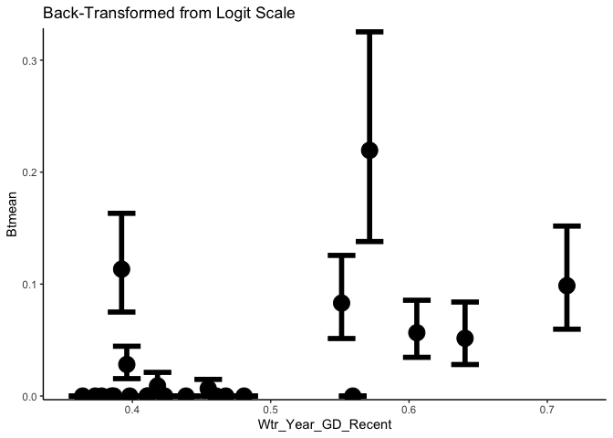

```r
wl2_logit_compare %>%
  ggplot(aes(x=Wtr_Year_GD_Recent, y=Btmean, group = pop)) +
  geom_point(size=6) +
  geom_errorbar(aes(ymin=BtLow,ymax=BtHigh), width=.02, linewidth = 2) +
  theme_classic() +
  scale_y_continuous(expand = c(0.01, 0)) +
  ggtitle("Back-Transformed from Logit Scale")
```

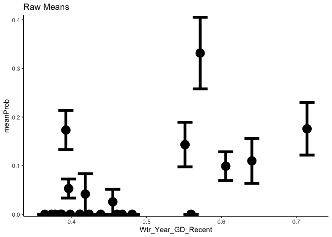

```r
wl2_logit_compare %>%
  ggplot(aes(x=Wtr_Year_GD_Recent, y=meanProb, group = pop)) +
  geom_point(size=6) +
  geom_errorbar(aes(ymin=meanProb-semProb,ymax=meanProb+semProb), width=.02, linewidth = 2) +
  theme_classic() +
  scale_y_continuous(expand = c(0.01, 0)) +
  ggtitle("Raw Means")
```

Make comparison figures - With 0s removed

```r
wl2_logit_compare2 <- wl2_prob_fit_block_summary %>%
  filter(meanProbBlock>0, meanProbBlock<1) %>%
  mutate(logitBlockMean=car::logit(meanProbBlock, adjust = 0.025)) %>%
  ungroup() %>%
  group_by(pop, Geographic_Dist,
           Wtr_Year_GD_Recent, Wtr_Year_GD_Historical,
           GrwSsn_GD_Recent, GrwSsn_GD_Historical) %>%
  summarise(meanProb=mean(meanProbBlock, na.rm=TRUE),
            semProb=sem(meanProbBlock, na.rm=TRUE),
            meanLogit=mean(logitBlockMean, na.rm=TRUE),
            semLogit=sem(logitBlockMean, na.rm=TRUE)) %>%
  mutate(Btmean=inv.logit(meanLogit, a=0.025)) %>%
  mutate(HighError=meanLogit+semLogit, LowError=meanLogit-semLogit) %>%
  mutate(Btmean=inv.logit(meanLogit, a=0.025),
         BtHigh=inv.logit(HighError, a=0.025),
         BtLow=inv.logit(LowError, a=0.025))
```

```
## 'Wtr_Year_GD_Recent', 'Wtr_Year_GD_Historical', 'GrwSsn_GD_Recent'. You can
```

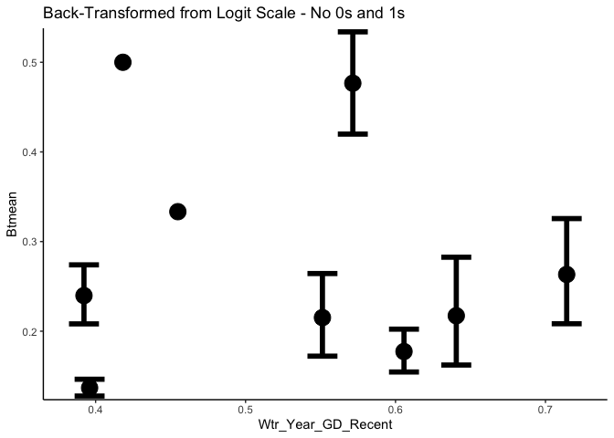

```r
wl2_logit_compare2 %>%
  ggplot(aes(x=Wtr_Year_GD_Recent, y=Btmean, group = pop)) +
  geom_point(size=6) +
  geom_errorbar(aes(ymin=BtLow,ymax=BtHigh), width=.02, linewidth = 2) +
  theme_classic() +
  scale_y_continuous(expand = c(0.01, 0)) +
  ggtitle("Back-Transformed from Logit Scale - No 0s and 1s")
```

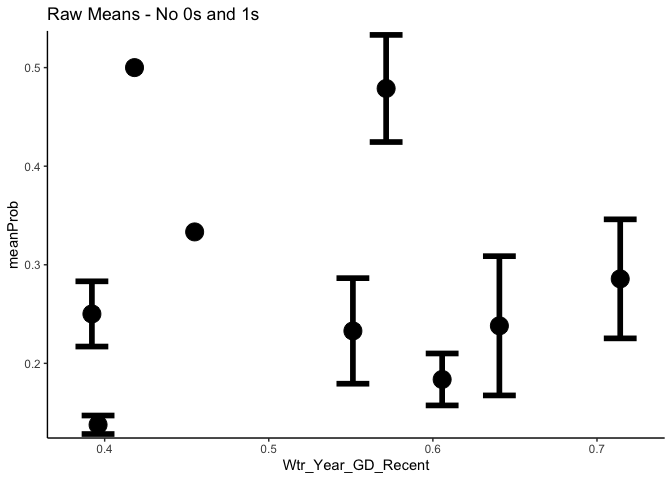

```r
wl2_logit_compare2 %>%
  ggplot(aes(x=Wtr_Year_GD_Recent, y=meanProb, group = pop)) +
  geom_point(size=6) +
  geom_errorbar(aes(ymin=meanProb-semProb,ymax=meanProb+semProb), width=.02, linewidth = 2) +
  theme_classic() +
  scale_y_continuous(expand = c(0.01, 0)) +
  ggtitle("Raw Means - No 0s and 1s")
```

Try boot::logit and boot::inv.logit

```r
#double check that back transformation works
wl2_prob_fit_block_summary %>%
  mutate(logitBlockMean=boot::logit(meanProbBlock + 0.001)) %>%
  mutate(btProb=boot::inv.logit(logitBlockMean)-0.001)
```

```
## # A tibble: 288 × 11
## # Groups:   pop, block, Geographic_Dist, Wtr_Year_GD_Recent,
## #   Wtr_Year_GD_Historical, GrwSsn_GD_Recent [288]
##    pop   block Geographic_Dist Wtr_Year_GD_Recent Wtr_Year_GD_Historical
##    <chr> <chr>           <dbl>              <dbl>                  <dbl>
##  1 BH    A             159626.              0.714                  0.647
##  2 BH    B             159626.              0.714                  0.647
##  3 BH    C             159626.              0.714                  0.647
##  4 BH    D             159626.              0.714                  0.647
##  5 BH    E             159626.              0.714                  0.647
##  6 BH    F             159626.              0.714                  0.647
##  7 BH    G             159626.              0.714                  0.647
##  8 BH    H             159626.              0.714                  0.647
##  9 BH    I             159626.              0.714                  0.647
## 10 BH    J             159626.              0.714                  0.647
## # ℹ 278 more rows
## # ℹ 6 more variables: GrwSsn_GD_Recent <dbl>, GrwSsn_GD_Historical <dbl>,
## #   meanProbBlock <dbl>, n <int>, logitBlockMean <dbl>, btProb <dbl>
```

```r
#means are wrong b/c of 0 conversions
boot::inv.logit((-0.911395862 +  -6.906754779)/2)-0.001 ##logit =  0.01866459
```

```
## [1] 0.01866459
```

```r
(2.857143e-01 + -4.336809e-19)/2 #non-logit = 0.1428571
```

```
## [1] 0.1428571
```

```r
boot::inv.logit((-0.911395862 +  0)/2)-0.001 #convert logit zeros = 0.3870069 - also wrong ...
```

```
## [1] 0.3870069
```

```r
#likely b/c when I'm taking the mean, the +0.001 is being manipulated??
#((x - lb) / (ub - lb))
```

```
## argument.
```

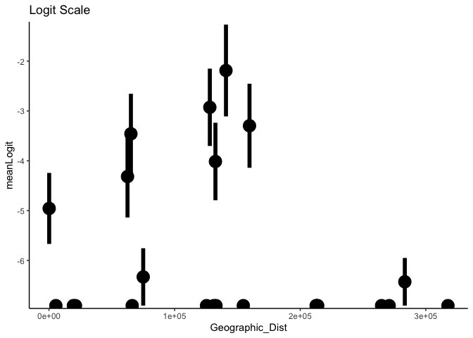

```r
##logit scale
wl2_prob_fit_block_summary %>%
  mutate(logitBlockMean=boot::logit(meanProbBlock + 0.001)) %>%
  group_by(pop, Geographic_Dist) %>%
  summarise(meanLogit=mean(logitBlockMean),
            semLogit=sem(logitBlockMean)) %>%
  ggplot(aes(x=Geographic_Dist, y=meanLogit, group = pop)) +
  geom_point(size=6) +
  geom_errorbar(aes(ymin=meanLogit+semLogit,ymax=meanLogit-semLogit),width=.2, linewidth = 2) +
  theme_classic() +
  scale_y_continuous(expand = c(0.01, 0)) +
  ggtitle("Logit Scale")
```

```
## argument.
```

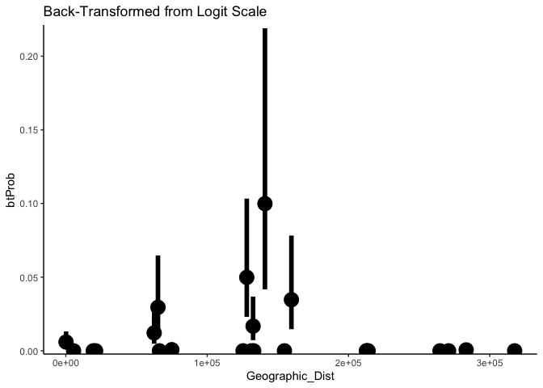

```r
##back transformed from logit
wl2_prob_fit_block_summary %>%
  mutate(logitBlockMean=boot::logit(meanProbBlock + 0.001)) %>%
  group_by(pop, Geographic_Dist) %>%
  summarise(meanLogit=mean(logitBlockMean),
            semLogit=sem(logitBlockMean)) %>%
    mutate(HighError=meanLogit+semLogit, LowError=meanLogit-semLogit) %>%
  mutate(btProb=boot::inv.logit(meanLogit)-0.001,
         btHighError=boot::inv.logit(HighError)-0.001,
         btLowError=boot::inv.logit(LowError)-0.001) %>%
  ggplot(aes(x=Geographic_Dist, y=btProb, group = pop)) +
  geom_point(size=6) +
  geom_errorbar(aes(ymin=btLowError,ymax=btHighError),width=.2, linewidth = 2) +
  theme_classic() +
  scale_y_continuous(expand = c(0.01, 0)) +
  ggtitle("Back-Transformed from Logit Scale")
```

```
## argument.
```

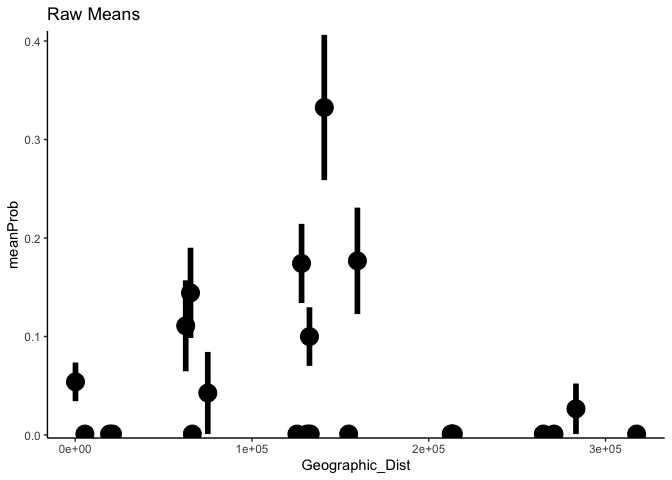

```r
##non-logit scale
wl2_total_fitness_sub_dist %>%
  mutate(ProbFitness=if_else(Total_Fitness==0, 0, 1)) %>%
  group_by(pop, block, Geographic_Dist) %>%
  summarise(meanProbBlock=mean(ProbFitness, na.rm = TRUE) + 0.001, n=n()) %>%
  group_by(pop, Geographic_Dist) %>%
  summarise(meanProb=mean(meanProbBlock, na.rm = TRUE),
            semProb=sem(meanProbBlock,  na.rm=TRUE)) %>%
  ggplot(aes(x=Geographic_Dist, y=meanProb, group = pop)) +
  geom_point(size=6) +
  geom_errorbar(aes(ymin=meanProb-semProb,ymax=meanProb+semProb),width=.2, linewidth = 2) +
  theme_classic() +
  scale_y_continuous(expand = c(0.01, 0)) +
  ggtitle("Raw Means")
```

#### Basic Model Workflow

```r
glmer.model_binomial <-
  linear_reg() %>%
  set_engine("glmer", family=binomial)

prob_fitness_wflow <- workflow() %>%
  add_variables(outcomes = ProbFitness, predictors = c(pop, mf, block))

prob_fitness_fits <- tibble(wflow=list(
  pop = {prob_fitness_wflow %>%
      add_model(glmer.model_binomial, formula = ProbFitness ~ (1|pop))},

  pop.mf = {prob_fitness_wflow %>%
      add_model(glmer.model_binomial, formula = ProbFitness ~ (1|pop/mf))},

  pop.block = {prob_fitness_wflow %>%
      add_model(glmer.model_binomial, formula = ProbFitness ~ (1|pop) + (1|block))},

  pop.mf.block = {prob_fitness_wflow %>%
      add_model(glmer.model_binomial, formula = ProbFitness ~ (1|pop/mf) + (1|block))}
),
name=names(wflow)
) %>%
  select(name,wflow)

prob_fitness_fits_wl2 <- prob_fitness_fits %>%
  mutate(fit = map(wflow, fit, data = wl2_prob_fitness))
#mod_test <- glmer(ProbFitness ~ (1|pop/mf), data=wl2_prob_fitness, family=binomial)
#Warning: Model failed to converge with max|grad| = 0.0846977 (tol = 0.002, component 1)Warning: Model is nearly unidentifiable: very large eigenvalue
 #- Rescale variables? But can't scale character variables, maybe something wrong with mf sample sizes
#summary(mod_test)

prob_fitness_fits_ucd <- prob_fitness_fits %>%
  mutate(fit = map(wflow, fit, data = ucd_prob_fitness))

prob_fitness_fits_wl2 %>% mutate(glance=map(fit, glance)) %>% unnest(glance) %>% arrange(AIC) %>% select(-wflow:-sigma)
```

```
## # A tibble: 4 × 6
##   name         logLik   AIC   BIC deviance df.residual
##   <chr>         <dbl> <dbl> <dbl>    <dbl>       <int>
## 1 pop.block     -280.  567.  583.     476.        1570
## 2 pop.mf.block  -280.  568.  589.     456.        1569
## 3 pop           -292.  589.  599.     528.        1571
## 4 pop.mf        -292.  590.  606.     511.        1570
```

```r
#model with pop and block (but excluding mf) is best by AIC and BIC

prob_fitness_fits_ucd %>% mutate(glance=map(fit, glance)) %>% unnest(glance) %>% arrange(AIC) %>% select(-wflow:-sigma)
```

```
## # A tibble: 4 × 6
##   name         logLik   AIC   BIC deviance df.residual
##   <chr>         <dbl> <dbl> <dbl>    <dbl>       <int>
## 1 pop.mf        -97.1  200.  214.     146.         752
## 2 pop           -98.9  202.  211.     169.         753
## 3 pop.mf.block  -97.1  202.  221.     143.         751
## 4 pop.block     -98.9  204.  218.     168.         752
```

```r
#model with pop and mf (but excluding block) preferred by AIC, model with just pop preferred by BIC
```

#### VISUALIZE

```r
prob_fitness_nd_wl2 <- data_grid(wl2_prob_fitness, pop)

prob_fitness_predict_fun <- function(m, nd = prob_fitness_nd_wl2) {
  predict(m,
          newdata = nd,
          type = "response",
          re.form = ~(1|pop)
  )
}

# 100 seconds
system.time (prob_fitness_fits_wl2 <- prob_fitness_fits_wl2 %>%
               mutate(
                 bootstrap = map(fit, \(x) {
                   extract_fit_engine(x) %>%
                     bootMer(FUN = prob_fitness_predict_fun,
                             re.form = ~ (1|pop),
                             nsim = 1000,
                             parallel = "multicore",
                             ncpus = 7
                     ) } #bootMer
                 ),
                 tidyboot = map(bootstrap, tidy, conf.int = TRUE),
                 tidyboot = map(tidyboot, \(x) cbind(prob_fitness_nd_wl2, x))
               ) # mutate
) # system.time

prob_fitness_fits_wl2 %>%
  select(name, tidyboot) %>%
  unnest(tidyboot) %>%
  ggplot(aes(x=pop)) +
  geom_col(aes(y=Survival), data = wl2_estab_means, fill="skyblue") +
  geom_pointrange(aes(y=statistic, ymax = conf.high, ymin = conf.low, color=name), position = position_dodge(width = .75)) +
  ylab("Prob Fitness >0") +
  scale_color_viridis_d() +
  theme(axis.text.x = element_text(angle=90, hjust=1, vjust=.5))
#the model with pop and block seems to be underestimating the means whereas the model with just pop seems to match the data better...

#wl2_estab_means %>%
#  ggplot(aes(x=pop, y=Survival)) +
#  geom_col()

#prob_fitness_fits_wl2 %>%
#  select(name, bootstrap) %>%
#  mutate(tidyboot = map(bootstrap, tidy, conf.int = TRUE)) %>%
#  unnest(tidyboot)
```

```r
prob_fitness_nd_ucd <- data_grid(ucd_prob_fitness, pop)

prob_fitness_predict_fun <- function(m, nd = prob_fitness_nd_ucd) {
  predict(m,
          newdata = nd,
          type = "response",
          re.form = ~(1|pop)
  )
}

# 100 seconds
system.time (prob_fitness_fits_ucd <- prob_fitness_fits_ucd %>%
               mutate(
                 bootstrap = map(fit, \(x) {
                   extract_fit_engine(x) %>%
                     bootMer(FUN = prob_fitness_predict_fun,
                             re.form = ~ (1|pop),
                             nsim = 1000,
                             parallel = "multicore",
                             ncpus = 7
                     ) } #bootMer
                 ),
                 tidyboot = map(bootstrap, tidy, conf.int = TRUE),
                 tidyboot = map(tidyboot, \(x) cbind(prob_fitness_nd_ucd, x))
               ) # mutate
) # system.time

prob_fitness_fits_ucd %>%
  select(name, tidyboot) %>%
  unnest(tidyboot) %>%
  ggplot(aes(x=pop)) +
  geom_col(aes(y=Survival), data = ucd_estab_means, fill="skyblue") +
  geom_pointrange(aes(y=statistic, ymax = conf.high, ymin = conf.low, color=name), position = position_dodge(width = .75)) +
   ylab("Prob Fitness >0") +
  scale_color_viridis_d() +
  theme(axis.text.x = element_text(angle=90, hjust=1, vjust=.5))
#pop.mf seems to be underestimating the means, model with just pop seems to match the data better...
```

#### Test climate and geographic distance

```r
prob_fitness_GD_wflow_wl2 <- workflow() %>%
  add_variables(outcomes = ProbFitness, predictors = c(pop, block, contains("GD"), Geographic_Dist))

prob_fitness_GD_fits_wl2 <- tibble(wflow=list(
  pop.block = {prob_fitness_GD_wflow_wl2 %>%
      add_model(glmer.model_binomial, formula = ProbFitness ~ (1|pop) + (1|block))},

  GS_Recent = {prob_fitness_GD_wflow_wl2 %>%
      add_model(glmer.model_binomial, formula = ProbFitness ~ GrwSsn_GD_Recent + Geographic_Dist + (1|pop) + (1|block))},

  GS_Historical = {prob_fitness_GD_wflow_wl2 %>%
      add_model(glmer.model_binomial, formula = ProbFitness ~ GrwSsn_GD_Historical + Geographic_Dist + (1|pop) + (1|block))},

  WY_Recent = {prob_fitness_GD_wflow_wl2 %>%
      add_model(glmer.model_binomial, formula = ProbFitness ~ Wtr_Year_GD_Recent + Geographic_Dist + (1|pop) + (1|block))},

  WY_Historical = {prob_fitness_GD_wflow_wl2 %>%
      add_model(glmer.model_binomial, formula = ProbFitness ~ Wtr_Year_GD_Historical + Geographic_Dist + (1|pop) + (1|block))}

),
name=names(wflow)
) %>%
  select(name,wflow) %>%
  mutate(fit = map(wflow, fit, data = wl2_prob_fitness))
prob_fitness_GD_fits_wl2 %>% mutate(glance=map(fit, glance)) %>% unnest(glance) %>% arrange(AIC) %>% select(-wflow:-sigma)
```

```
## # A tibble: 5 × 6
##   name          logLik   AIC   BIC deviance df.residual
##   <chr>          <dbl> <dbl> <dbl>    <dbl>       <int>
## 1 WY_Recent      -276.  561.  588.     477.        1568
## 2 WY_Historical  -278.  566.  592.     477.        1568
## 3 pop.block      -280.  567.  583.     476.        1570
## 4 GS_Historical  -280.  570.  597.     476.        1568
## 5 GS_Recent      -280.  570.  597.     476.        1568
```

```r
#water year models preferred by AIC

prob_fitness_GD_fits_wl2 %>% mutate(tidy=map(fit, tidy)) %>% unnest(tidy) %>%
  filter(str_detect(term, "GD") | term=="Geographic_Dist") %>%
  drop_na(p.value) %>%
  select(-wflow:-group)# %>%
```

```
## # A tibble: 8 × 6
##   name          term                   estimate std.error statistic p.value
##   <chr>         <chr>                     <dbl>     <dbl>     <dbl>   <dbl>
## 1 GS_Recent     GrwSsn_GD_Recent          0.217  0.000946   229.    0
## 2 GS_Recent     Geographic_Dist          -0.576  0.000946  -608.    0
## 3 GS_Historical GrwSsn_GD_Historical     -0.428  0.833       -0.513 0.608
## 4 GS_Historical Geographic_Dist          -0.540  0.759       -0.711 0.477
## 5 WY_Recent     Wtr_Year_GD_Recent        1.79   0.632        2.83  0.00473
## 6 WY_Recent     Geographic_Dist          -0.488  0.585       -0.834 0.404
## 7 WY_Historical Wtr_Year_GD_Historical    1.38   0.646        2.14  0.0324
## 8 WY_Historical Geographic_Dist          -0.506  0.640       -0.792 0.429
```

```r
#  arrange(p.value)
# recent and historical water year CD are sig, geo dist is not sig in those models. The GS_RECENT model had convergence issues.

mod_test <- glmer(ProbFitness ~ GrwSsn_GD_Recent + Geographic_Dist + (1|pop) + (1|block), data=wl2_prob_fitness, family=binomial)
#summary(mod_test)
#Warning: Model failed to converge with max|grad| = 0.0747217 (tol = 0.002, component 1)Warning: Model is nearly unidentifiable: very large eigenvalue
# - Rescale variables? - But the variables were already scaled
```

```r
prob_fitness_SUB_wflow_wl2 <- workflow() %>%
  add_variables(outcomes = ProbFitness, predictors = c(pop, block, contains("Dist")))

prob_fitness_SUB_fits_wl2 <- tibble(wflow=list(
  pop.block = {prob_fitness_SUB_wflow_wl2 %>%
      add_model(glmer.model_binomial, formula = ProbFitness ~ (1|pop) + (1|block))},

  GS_Recent = {prob_fitness_SUB_wflow_wl2 %>%
      add_model(glmer.model_binomial, formula = ProbFitness ~ GrwSsn_TempDist_Recent + GrwSsn_PPTDist_Recent+ Geographic_Dist + (1|pop) + (1|block))},

  GS_Historical = {prob_fitness_SUB_wflow_wl2 %>%
      add_model(glmer.model_binomial, formula = ProbFitness ~ GrwSsn_TempDist_Historic + GrwSsn_PPTDist_Historic + Geographic_Dist + (1|pop) + (1|block))},

  WY_Recent = {prob_fitness_SUB_wflow_wl2 %>%
      add_model(glmer.model_binomial, formula = ProbFitness ~ Wtr_Year_TempDist_Recent + Wtr_Year_PPTDist_Recent + Geographic_Dist + (1|pop) + (1|block))},

  WY_Historical = {prob_fitness_SUB_wflow_wl2 %>%
      add_model(glmer.model_binomial, formula = ProbFitness ~ Wtr_Year_TempDist_Historic + Wtr_Year_PPTDist_Historic + Geographic_Dist + (1|pop) + (1|block))}

),
name=names(wflow)
) %>%
  select(name,wflow) %>%
  mutate(fit = map(wflow, fit, data = wl2_prob_fitness_sub))

prob_fitness_SUB_fits_wl2 %>% mutate(glance=map(fit, glance)) %>% unnest(glance) %>% arrange(AIC) %>% select(-wflow:-sigma)
```

```
## # A tibble: 5 × 6
##   name          logLik   AIC   BIC deviance df.residual
##   <chr>          <dbl> <dbl> <dbl>    <dbl>       <int>
## 1 WY_Historical  -275.  561.  594.     477.        1567
## 2 WY_Recent      -275.  561.  594.     477.        1567
## 3 GS_Historical  -277.  565.  597.     476.        1567
## 4 GS_Recent      -277.  565.  598.     477.        1567
## 5 pop.block      -280.  567.  583.     476.        1570
```

```r
prob_fitness_SUB_fits_wl2 %>% mutate(tidy=map(fit, tidy)) %>% unnest(tidy) %>%
  filter(str_detect(term, "Dist") | term=="Geographic_Dist") %>%
  drop_na(p.value) %>%
  select(-wflow:-group)# %>%
```

```
## # A tibble: 12 × 6
##    name          term                       estimate std.error statistic p.value
##    <chr>         <chr>                         <dbl>     <dbl>     <dbl>   <dbl>
##  1 GS_Recent     GrwSsn_TempDist_Recent      -0.242      0.933   -0.260   0.795
##  2 GS_Recent     GrwSsn_PPTDist_Recent        1.96       0.978    2.01    0.0448
##  3 GS_Recent     Geographic_Dist              0.113      0.642    0.176   0.860
##  4 GS_Historical GrwSsn_TempDist_Historic     0.418      0.843    0.497   0.619
##  5 GS_Historical GrwSsn_PPTDist_Historic      1.55       0.807    1.92    0.0554
##  6 GS_Historical Geographic_Dist             -0.0568     0.631   -0.0900  0.928
##  7 WY_Recent     Wtr_Year_TempDist_Recent     1.78       0.741    2.40    0.0164
##  8 WY_Recent     Wtr_Year_PPTDist_Recent     -0.588      0.758   -0.775   0.438
##  9 WY_Recent     Geographic_Dist             -0.309      0.584   -0.528   0.597
## 10 WY_Historical Wtr_Year_TempDist_Historic   1.75       0.763    2.29    0.0222
## 11 WY_Historical Wtr_Year_PPTDist_Historic   -0.589      0.783   -0.753   0.452
## 12 WY_Historical Geographic_Dist             -0.239      0.566   -0.423   0.672
```

```r
#  arrange(p.value)

mod_test <- glmer(ProbFitness ~ GrwSsn_TempDist_Recent + GrwSsn_PPTDist_Recent+ Geographic_Dist + (1|pop) + (1|block), data=wl2_prob_fitness_sub, family=binomial)
summary(mod_test)
```

```
## Generalized linear mixed model fit by maximum likelihood (Laplace
##   Approximation) [glmerMod]
##  Family: binomial  ( logit )
## Formula: ProbFitness ~ GrwSsn_TempDist_Recent + GrwSsn_PPTDist_Recent +
##     Geographic_Dist + (1 | pop) + (1 | block)
##    Data: wl2_prob_fitness_sub
##
##      AIC      BIC   logLik deviance df.resid
##    565.4    597.6   -276.7    553.4     1567
##
## Scaled residuals:
##     Min      1Q  Median      3Q     Max
## -1.4228 -0.2611 -0.0441 -0.0288  4.9333
##
## Random effects:
##  Groups Name        Variance Std.Dev.
##  pop    (Intercept) 5.6844   2.3842
##  block  (Intercept) 0.7012   0.8374
## Number of obs: 1573, groups:  pop, 23; block, 13
##
## Fixed effects:
##                        Estimate Std. Error z value Pr(>|z|)
## (Intercept)             -5.3208     0.9429  -5.643 1.67e-08 ***
## GrwSsn_TempDist_Recent  -0.2424     0.9331  -0.260   0.7951
## GrwSsn_PPTDist_Recent    1.9625     0.9778   2.007   0.0448 *
## Geographic_Dist          0.1129     0.6417   0.176   0.8603
## ---
## Signif. codes:  0 '***' 0.001 '**' 0.01 '*' 0.05 '.' 0.1 ' ' 1
##
## Correlation of Fixed Effects:
##             (Intr) GS_TD_ GS_PPT
## GrwSsn_TD_R -0.173
## GrwS_PPTD_R -0.193 -0.658
## Gegrphc_Dst -0.090 -0.138  0.335
```

Model comparison

```r
m1 <-  glmer(ProbFitness ~ Wtr_Year_TempDist_Recent + GrwSsn_PPTDist_Recent + Geographic_Dist + (1|pop) + (1|block), data=wl2_prob_fitness_sub, family=binomial)
m2 <- glmer(ProbFitness ~ Wtr_Year_TempDist_Recent + Geographic_Dist + (1|pop) + (1|block), data=wl2_prob_fitness_sub, family=binomial)
m3 <- glmer(ProbFitness ~  GrwSsn_PPTDist_Recent + Geographic_Dist + (1|pop) + (1|block), data=wl2_prob_fitness_sub, family=binomial)
anova(m1, m2, m3)
```

```
## Data: wl2_prob_fitness_sub
## Models:
## m2: ProbFitness ~ Wtr_Year_TempDist_Recent + Geographic_Dist + (1 | pop) + (1 | block)
## m3: ProbFitness ~ GrwSsn_PPTDist_Recent + Geographic_Dist + (1 | pop) + (1 | block)
## m1: ProbFitness ~ Wtr_Year_TempDist_Recent + GrwSsn_PPTDist_Recent + Geographic_Dist + (1 | pop) + (1 | block)
##    npar    AIC    BIC  logLik deviance  Chisq Df Pr(>Chisq)
## m2    5 560.10 586.90 -275.05   550.10
## m3    5 563.50 590.30 -276.75   553.50 0.0000  0
## m1    6 562.05 594.22 -275.03   550.05 3.4449  1    0.06345 .
## ---
## Signif. codes:  0 '***' 0.001 '**' 0.01 '*' 0.05 '.' 0.1 ' ' 1
```

Keep block in for UCD

```r
prob_fitness_GD_wflow_ucd <- workflow() %>%
  add_variables(outcomes = ProbFitness, predictors = c(pop, mf, block, contains("GD"), Geographic_Dist))

prob_fitness_GD_fits_ucd <- tibble(wflow=list(
  pop.mf.block = {prob_fitness_GD_wflow_ucd %>%
      add_model(glmer.model_binomial, formula = ProbFitness ~ (1|pop/mf) + (1|block))},

  GS_Recent = {prob_fitness_GD_wflow_ucd %>%
      add_model(glmer.model_binomial, formula = ProbFitness ~ GrwSsn_GD_Recent + Geographic_Dist + (1|pop/mf) + (1|block))},

  GS_Historical = {prob_fitness_GD_wflow_ucd %>%
      add_model(glmer.model_binomial, formula = ProbFitness ~ GrwSsn_GD_Historical + Geographic_Dist + (1|pop/mf) + (1|block))},

  WY_Recent = {prob_fitness_GD_wflow_ucd %>%
      add_model(glmer.model_binomial, formula = ProbFitness ~ Wtr_Year_GD_Recent + Geographic_Dist + (1|pop/mf) + (1|block))},

  WY_Historical = {prob_fitness_GD_wflow_ucd %>%
      add_model(glmer.model_binomial, formula = ProbFitness ~ Wtr_Year_GD_Historical + Geographic_Dist + (1|pop/mf) + (1|block))}

),
name=names(wflow)
) %>%
  select(name,wflow) %>%
  mutate(fit = map(wflow, fit, data = ucd_prob_fitness))
prob_fitness_GD_fits_ucd %>% mutate(glance=map(fit, glance)) %>% unnest(glance) %>% arrange(AIC) %>% select(-wflow:-sigma)
```

```
## # A tibble: 5 × 6
##   name          logLik   AIC   BIC deviance df.residual
##   <chr>          <dbl> <dbl> <dbl>    <dbl>       <int>
## 1 pop.mf.block   -97.1  202.  221.     143.         751
## 2 WY_Historical  -95.9  204.  232.     146.         749
## 3 WY_Recent      -96.0  204.  232.     145.         749
## 4 GS_Recent      -96.9  206.  234.     144.         749
## 5 GS_Historical  -97.0  206.  234.     144.         749
```

```r
#pop.mf.block preferred by AIC & BIC, WY models are close after

prob_fitness_GD_fits_ucd %>% mutate(tidy=map(fit, tidy)) %>% unnest(tidy) %>%
  filter(str_detect(term, "GD") | term=="Geographic_Dist") %>%
  drop_na(p.value) %>%
  select(-wflow:-group)# %>%
```

```
## # A tibble: 8 × 6
##   name          term                   estimate std.error statistic   p.value
##   <chr>         <chr>                     <dbl>     <dbl>     <dbl>     <dbl>
## 1 GS_Recent     GrwSsn_GD_Recent         0.515    0.00139   370.    0
## 2 GS_Recent     Geographic_Dist         -0.436    0.00139  -314.    0
## 3 GS_Historical GrwSsn_GD_Historical    -0.163    0.880      -0.185 8.53e-  1
## 4 GS_Historical Geographic_Dist         -0.202    0.758      -0.266 7.90e-  1
## 5 WY_Recent     Wtr_Year_GD_Recent      -1.16     0.00146  -796.    0
## 6 WY_Recent     Geographic_Dist          0.0523   0.00146    35.7   7.54e-280
## 7 WY_Historical Wtr_Year_GD_Historical  -1.26     0.808      -1.56  1.19e-  1
## 8 WY_Historical Geographic_Dist          0.179    0.625       0.287 7.74e-  1
```

```r
#  arrange(p.value)

mod_test <- glmer(ProbFitness ~ Wtr_Year_GD_Historical + Geographic_Dist + (1|pop/mf) + (1|block), data=ucd_prob_fitness, family=binomial)
#model failed to converge for growth season and water year recent
```

```r
prob_fitness_SUB_wflow_ucd <- workflow() %>%
  add_variables(outcomes = ProbFitness, predictors = c(pop, mf, block, contains("Dist")))

prob_fitness_SUB_fits_ucd <- tibble(wflow=list(
  pop.block = {prob_fitness_SUB_wflow_ucd %>%
      add_model(glmer.model_binomial, formula = ProbFitness ~ (1|pop/mf) + (1|block))},

  GS_Recent = {prob_fitness_SUB_wflow_ucd %>%
      add_model(glmer.model_binomial, formula = ProbFitness ~ GrwSsn_TempDist_Recent + GrwSsn_PPTDist_Recent+ Geographic_Dist + (1|pop/mf) + (1|block))},

  GS_Historical = {prob_fitness_SUB_wflow_ucd %>%
      add_model(glmer.model_binomial, formula = ProbFitness ~ GrwSsn_TempDist_Historic + GrwSsn_PPTDist_Historic + Geographic_Dist + (1|pop/mf) + (1|block))},

  WY_Recent = {prob_fitness_SUB_wflow_ucd %>%
      add_model(glmer.model_binomial, formula = ProbFitness ~ Wtr_Year_TempDist_Recent + Wtr_Year_PPTDist_Recent + Geographic_Dist + (1|pop/mf) + (1|block))},

  WY_Historical = {prob_fitness_SUB_wflow_ucd %>%
      add_model(glmer.model_binomial, formula = ProbFitness ~ Wtr_Year_TempDist_Historic + Wtr_Year_PPTDist_Historic + Geographic_Dist + (1|pop/mf) + (1|block))}

),
name=names(wflow)
) %>%
  select(name,wflow) %>%
  mutate(fit = map(wflow, fit, data = ucd_prob_fitness_sub))
prob_fitness_SUB_fits_ucd %>% mutate(glance=map(fit, glance)) %>% unnest(glance) %>% arrange(AIC) %>% select(-wflow:-sigma)
```

```
## # A tibble: 5 × 6
##   name          logLik   AIC   BIC deviance df.residual
##   <chr>          <dbl> <dbl> <dbl>    <dbl>       <int>
## 1 pop.block      -97.1  202.  221.     143.         751
## 2 WY_Recent      -95.6  205.  237.     146.         748
## 3 WY_Historical  -95.6  205.  238.     145.         748
## 4 GS_Recent      -96.4  207.  239.     144.         748
## 5 GS_Historical  -96.5  207.  239.     145.         748
```

```r
prob_fitness_SUB_fits_ucd %>% mutate(tidy=map(fit, tidy)) %>% unnest(tidy) %>%
  filter(str_detect(term, "Dist") | term=="Geographic_Dist") %>%
  drop_na(p.value) %>%
  select(-wflow:-group)# %>%
```

```
## # A tibble: 12 × 6
##    name          term                      estimate std.error statistic  p.value
##    <chr>         <chr>                        <dbl>     <dbl>     <dbl>    <dbl>
##  1 GS_Recent     GrwSsn_TempDist_Recent     -0.739    0.845      -0.875 3.82e- 1
##  2 GS_Recent     GrwSsn_PPTDist_Recent       1.24     1.08        1.15  2.49e- 1
##  3 GS_Recent     Geographic_Dist             0.369    0.897       0.412 6.81e- 1
##  4 GS_Historical GrwSsn_TempDist_Historic   -0.302    0.774      -0.390 6.97e- 1
##  5 GS_Historical GrwSsn_PPTDist_Historic     0.920    0.837       1.10  2.72e- 1
##  6 GS_Historical Geographic_Dist             0.194    0.833       0.232 8.16e- 1
##  7 WY_Recent     Wtr_Year_TempDist_Recent    0.541    0.00150   359.    0
##  8 WY_Recent     Wtr_Year_PPTDist_Recent    -1.00     0.00150  -667.    0
##  9 WY_Recent     Geographic_Dist            -0.0318   0.00150   -21.2   2.00e-99
## 10 WY_Historical Wtr_Year_TempDist_Histor…   0.593    0.00151   392.    0
## 11 WY_Historical Wtr_Year_PPTDist_Historic  -0.908    0.00151  -600.    0
## 12 WY_Historical Geographic_Dist             0.0103   0.00151     6.80  1.06e-11
```

```r
#  arrange(p.value)

mod_test <- glmer(ProbFitness ~ Wtr_Year_TempDist_Historic + Wtr_Year_PPTDist_Historic + Geographic_Dist + (1|pop/mf) + (1|block), data=ucd_prob_fitness_sub, family=binomial)
#Water year recent and historic models failed to converge
```